# Data Science Challenge: Shivam Thassu

**Candidate ID: C1084391**  
**Version: v20.01**

**Data Science Challenge: Card Transactions!**

# Packages Required & Functions

```python
# All necessary Packages

import os
import json
import sys
import csv
import codecs
import warnings
import pandasql as ps
import pandas as pd
import numpy as np
from ctypes import cdll
from collections import Counter
import matplotlib.pyplot as plt
import seaborn as sns
warnings.filterwarnings('ignore')
pd.set_option('display.max_columns', None)
%config InlineBackend.figure_format = 'retina'
sys.setrecursionlimit(1500)

# Import Pipeline pckgs

from sklearn.pipeline import Pipeline
from sklearn.preprocessing import StandardScaler
from sklearn.feature_selection import VarianceThreshold
from sklearn.model_selection import RandomizedSearchCV,StratifiedKFold,train_test_split,cross_val_predict

# Import Classifier models

from sklearn.ensemble import RandomForestClassifier,GradientBoostingClassifier
from imblearn.ensemble import BalancedRandomForestClassifier,EasyEnsembleClassifier
from sklearn.linear_model import LogisticRegression
import xgboost as xgb
from sklearn.ensemble import VotingClassifier
from sklearn.tree import DecisionTreeClassifier
from sklearn.svm import SVC
from xgboost import XGBClassifier
from xgboost import plot_importance

# Import Metric pckgs

from sklearn import metrics
from sklearn.metrics import confusion_matrix,classification_report,plot_precision_recall_curve
from sklearn.metrics import roc_auc_score,roc_curve, auc, average_precision_score,precision_recall_curve
from sklearn.metrics import precision_score,accuracy_score,recall_score
```

```python
# Function to plot distplot

def plot_dist(col,title):
    """
    col  : column name
    title: title of the plot (string value)
    """
    #import seaborn as sns
    #import matplotlib.pyplot as plt
    plt.figure(figsize=(16,9))
    sns.set() # for style
    sns.distplot(col)
    #plt.xticks([1.0,1.5,2.0,2.5,3.0,3.5,4.0,4.5,5.0])
    plt.title(title,fontdict= {'fontsize': 24, 'fontweight':'bold'})
    #plt.legend()

# Function to plot barplot

def plot_bar(inp_data,x_axis,x_label,y_label,title):
    """
    inp_data : input dataframe
    x_axis   : column on x_axis (string value)
    x_label  : name on x_label (string value)
    y_label  : name on y_label (string value)
    title    : title of the plot (string value)
    """
    try:
        #import seaborn as sns
        #warnings.filterwarnings('ignore')
        #import matplotlib.pyplot as plt
        sns.set_style(style="darkgrid")
        plt.figure(figsize=(16, 9))
        fig = sns.countplot(x=x_axis,data=inp_data,order=inp_data[x_axis].value_counts().index)
        plt.xlabel(x_label,fontdict= {'fontsize': 18,'fontweight':'bold'},labelpad=20)
        plt.ylabel(y_label,fontdict= {'fontsize': 18,'fontweight':'bold'},labelpad=20)
        plt.title(title,fontdict= { 'fontsize': 24, 'fontweight':'bold'},pad=20)
        plt.xticks(fontsize=13,rotation=45)
        plt.yticks(fontsize=13)
        for p in fig.patches:
            fig.annotate('{:.0f}'.format(p.get_height()), (p.get_x()+0.2, p.get_height()+100),fontsize=12)
        plt.show(fig)
    except TypeError:
        pass
```

```python
# Confusion Matrix

def cnf_matrix(y_test,pred,mod_name):
    """
    y_test   : y_test after train/test split
    pred     : model.predict(X_test)
    mod_name : name of model (string value)
    """
    cm = confusion_matrix(y_test, pred)
    tn, fp, fn, tp = confusion_matrix(y_test, pred).ravel()
    cm = [[tp,fp],[fn,tn]]
    fig, ax = plt.subplots(figsize=(4,4))
    sns.heatmap(cm, annot=True, fmt = "d",cbar=False) #cmap='Blues'
    plt.xlabel('Actual Labels',fontdict= {'fontsize': 12},labelpad=20)
    plt.ylabel('Predicted Labels',fontdict= {'fontsize': 12},labelpad=20)
    plt.title(mod_name+' Regression Confusion Matrix',fontdict= { 'fontsize': 18, 'fontweight':'bold'},pad=20)
    ax.xaxis.set_ticklabels(['Fraud', 'Not Fraud'])
    ax.yaxis.set_ticklabels(['Fraud', 'Not Fraud'])
```

```python
# ROC_AUC curve

def plot_roc(y_test, pred_dict):
    """
    y_test    : y_test after train/test split
    pred_dict : dict consiting of key->string name of model,
                value->predicted probabilities
    """
    plt.title('ROC-AUC')
    plt.plot([0, 1], [0, 1],'r--')
    plt.xlim([0, 1])
    plt.ylim([0, 1])
    plt.ylabel('True Positive Rate')
    plt.xlabel('False Positive Rate')
    for key, pred in pred_dict.items():
        fpr, tpr, threshold = metrics.roc_curve(y_test, pred)
        roc_auc = metrics.auc(fpr, tpr)
        plt.plot(fpr, tpr, label = '%25s AUC = %0.3f' % (key, roc_auc))
    plt.legend(loc = 'lower right')
    plt.show()
```

```python
# Feature Importance

def plot_feature_importance(importance, names, mod_name):
    """
    importance : model.feature_importances_
    names      : X_train.columns
    mod_name   : name of model (string value)
    """
    feature_importance = np.array(importance)
    feature_names = np.array(names)
    data = {'feature_names': feature_names,
            'feature_importance': feature_importance}
    fi_df = pd.DataFrame(data)
    fi_df.sort_values(by=['feature_importance'], ascending=False, inplace=True)
    fi_df = fi_df[:15]
    plt.figure(figsize=(16, 9))
    sns.barplot(x=fi_df['feature_importance'],
                y=fi_df['feature_names'])
    plt.title(mod_name + " " + 'Feature Importance (Top 15)',
              weight='bold')
    plt.xlabel('Feature Importance')
    plt.ylabel('Feature Names')
```

```python
# PR Curve

def plot_pr_curve(y_test, pred_proba, mod_name):
    """
    y_test     : y_test after train/test split
    pred_proba : predicted probabilities
    mod_name   : name of model (string value)

    """
    precision, recall, _ = precision_recall_curve(y_test, pred_proba)
    plt.plot(recall, precision, marker='.', label=mod_name)
    plt.xlabel('Recall')
    plt.ylabel('Precision')
    plt.legend()
    plt.show()
```

```python
# Classification Report

def report_classification(mod_report):
    """
    mod_report : dict consiting of key->string name of model,
                 value-> predicted value
    """
    for k,v in mod_report.items():
        print('Classification Report for '+k)
        print(classification_report(y_test, v))
        print('--------------------------------------------------------------')
```

```python
# AUC & PR score

def roc_auc_pr(mod_report):
    """
    mod_report : dict consiting of key->string name of model,
                 value-> predicted probabilities
    """
    for k,v in mod_report.items():
        print('ROC-AUC score for '+k+':')
        print(round(roc_auc_score(y_test, v),4))
        print('\n')
        print('PR-AUC score for '+k)
        precision, recall, _ = precision_recall_curve(y_test, v)
        print(round(auc(recall, precision),4))
        print('---------------------------')
```

# Question 1: Load

## 1.1 Programmatically download and load into your favorite analytical tool the transactions data. This data, which is in line-delimited JSON format, can be found here

Download the data

```python
#import subprocess
#subprocess.run(["git","clone", "https://github.com/CapitalOneRecruiting/DS.git"])
#subprocess.run(["unzip","./DS/transactions.zip"])
```

```python
df = pd.read_json('C:/Users/shiva/Desktop/DS/transactions/transactions.txt', lines='True')
```

```python
df.head()
```

|  | accountNumber | customerId | creditLimit | availableMoney | transactionDateTime | transactionAmount | merchantName | acqCountry | merchantCountryCode | posEntryMode | posConditionCode | merchantCategoryCode | currentExpDate | accountOpenDate | dateOfLastAddressChange | cardCVV | enteredCVV | cardLast4Digits | transactionType | echoBuffer | currentBalance | merchantCity | merchantState | merchantZip | cardPresent | posOnPremises | recurringAuthInd | expirationDateKeyInMatch | isFraud |
| --- | --- | --- | --- | --- | --- | --- | --- | --- | --- | --- | --- | --- | --- | --- | --- | --- | --- | --- | --- | --- | --- | --- | --- | --- | --- | --- | --- | --- | --- |
| 0 | 737265056 | 737265056 | 5000 | 5000.0 | 2016-08-13T14:27:32 | 98.55 | Uber | US | US | 02 | 01 | rideshare | 06/2023 | 2015-03-14 | 2015-03-14 | 414 | 414 | 1803 | PURCHASE |  | 0.0 |  |  |  | False |  |  | False | False |
| 1 | 737265056 | 737265056 | 5000 | 5000.0 | 2016-10-11T05:05:54 | 74.51 | AMC #191138 | US | US | 09 | 01 | entertainment | 02/2024 | 2015-03-14 | 2015-03-14 | 486 | 486 | 767 | PURCHASE |  | 0.0 |  |  |  | True |  |  | False | False |
| 2 | 737265056 | 737265056 | 5000 | 5000.0 | 2016-11-08T09:18:39 | 7.47 | Play Store | US | US | 09 | 01 | mobileapps | 08/2025 | 2015-03-14 | 2015-03-14 | 486 | 486 | 767 | PURCHASE |  | 0.0 |  |  |  | False |  |  | False | False |
| 3 | 737265056 | 737265056 | 5000 | 5000.0 | 2016-12-10T02:14:50 | 7.47 | Play Store | US | US | 09 | 01 | mobileapps | 08/2025 | 2015-03-14 | 2015-03-14 | 486 | 486 | 767 | PURCHASE |  | 0.0 |  |  |  | False |  |  | False | False |
| 4 | 830329091 | 830329091 | 5000 | 5000.0 | 2016-03-24T21:04:46 | 71.18 | Tim Hortons #947751 | US | US | 02 | 01 | fastfood | 10/2029 | 2015-08-06 | 2015-08-06 | 885 | 885 | 3143 | PURCHASE |  | 0.0 |  |  |  | True |  |  | False | False |

## 1.2 Please describe the structure of the data. Number of records and fields in each record?

```python
df.shape
```

```
(786363, 29)
```

*The data set has 786363 rows and 29 columns*

## 1.3 Please provide some additional basic summary statistics for each field. Be sure to include a count of null, minimum, maximum, and unique values where appropriate.

```python
df.info()
```

```
<class 'pandas.core.frame.DataFrame'>
RangeIndex: 786363 entries, 0 to 786362
Data columns (total 29 columns):
 #   Column                    Non-Null Count   Dtype
---  ------                    --------------   -----
 0   accountNumber             786363 non-null  int64
 1   customerId                786363 non-null  int64
 2   creditLimit               786363 non-null  int64
 3   availableMoney            786363 non-null  float64
 4   transactionDateTime       786363 non-null  object
 5   transactionAmount         786363 non-null  float64
 6   merchantName              786363 non-null  object
 7   acqCountry                786363 non-null  object
 8   merchantCountryCode       786363 non-null  object
 9   posEntryMode              786363 non-null  object
```

[output cut: 21 more lines]

**Check for Null values**

```python
# Checking for empty string
for col in df.columns:
    print(col,(df[col] == "").sum())
```

```
accountNumber 0
customerId 0
creditLimit 0
availableMoney 0
transactionDateTime 0
transactionAmount 0
merchantName 0
acqCountry 4562
merchantCountryCode 724
posEntryMode 4054
posConditionCode 409
merchantCategoryCode 0
currentExpDate 0
accountOpenDate 0
dateOfLastAddressChange 0
cardCVV 0
enteredCVV 0
cardLast4Digits 0
transactionType 698
echoBuffer 786363
currentBalance 0
merchantCity 786363
merchantState 786363
merchantZip 786363
cardPresent 0
posOnPremises 786363
recurringAuthInd 786363
expirationDateKeyInMatch 0
isFraud 0
```

*There are some columns which are completely empty*

1. merchantCity
2. merchantState
3. merchantZip
4. posOnPremises
5. recurringAuthInd
6. echoBuffer

*There are some columns with few empty string values*

1. acqCountry
2. merchantCountryCode
3. posEntryMode
4. posConditionCode
5. transactionType

```python
# Dropping columns with no values

df.drop(['echoBuffer','merchantCity','merchantState','merchantZip','posOnPremises','recurringAuthInd'],
                  axis=1,inplace=True)
```

Converting date objects to Datetime dtype and breaking down and grouping data by dtypes for simplifying summary stats

```python
# Converting all date objects to Datetime dtype

df[['transactionDateTime', 'accountOpenDate', 'currentExpDate', 'dateOfLastAddressChange']] = df[[
    'transactionDateTime', 'accountOpenDate', 'currentExpDate', 'dateOfLastAddressChange']].apply(pd.to_datetime)
```

```python
# For simplicity breaking down data by dtypes to do summary statistics

# Numeric columns (int & float)
df_num_cols = df.select_dtypes(include=[np.number])

# Boolean columns
df_bool_cols = df.select_dtypes(include=['bool'])

# Object columns
df_obj_cols = df.select_dtypes(include=['object'])

# Date columns
df_date_cols = df.select_dtypes(include=['datetime64'])
```

*Data types*

- bool: 3
- float: 3
- int: 6
- object: 7
- datetime: 4

### Summary Stats & Observations for Numeric dtype columns

```python
df_num_cols.describe()
```

|  | accountNumber | customerId | creditLimit | availableMoney | transactionAmount | cardCVV | enteredCVV | cardLast4Digits | currentBalance |
| --- | --- | --- | --- | --- | --- | --- | --- | --- | --- |
| count | 7.863630e+05 | 7.863630e+05 | 786363.000000 | 786363.000000 | 786363.000000 | 786363.000000 | 786363.000000 | 786363.000000 | 786363.000000 |
| mean | 5.372326e+08 | 5.372326e+08 | 10759.464459 | 6250.725369 | 136.985791 | 544.467338 | 544.183857 | 4757.417799 | 4508.739089 |
| std | 2.554211e+08 | 2.554211e+08 | 11636.174890 | 8880.783989 | 147.725569 | 261.524220 | 261.551254 | 2996.583810 | 6457.442068 |
| min | 1.000881e+08 | 1.000881e+08 | 250.000000 | -1005.630000 | 0.000000 | 100.000000 | 0.000000 | 0.000000 | 0.000000 |
| 25% | 3.301333e+08 | 3.301333e+08 | 5000.000000 | 1077.420000 | 33.650000 | 310.000000 | 310.000000 | 2178.000000 | 689.910000 |
| 50% | 5.074561e+08 | 5.074561e+08 | 7500.000000 | 3184.860000 | 87.900000 | 535.000000 | 535.000000 | 4733.000000 | 2451.760000 |
| 75% | 7.676200e+08 | 7.676200e+08 | 15000.000000 | 7500.000000 | 191.480000 | 785.000000 | 785.000000 | 7338.000000 | 5291.095000 |
| max | 9.993896e+08 | 9.993896e+08 | 50000.000000 | 50000.000000 | 2011.540000 | 998.000000 | 998.000000 | 9998.000000 | 47498.810000 |

*This gives a general overview of min, max & mean values for these columns. Lets take a deep dive into each of these columns*

```python
# Checking the relationship between account number and customer id

df_num_cols.accountNumber.equals(df_num_cols.customerId)
```

```
True
```

- There is a one to one relationship between account number and customer id, infact both are identical.  
  This is to be noted for later on during feature engineering process

```python
# Checking to see if a customer has one card associated or multiple

df_num_cols.groupby('customerId')['cardLast4Digits'].nunique().sort_values(ascending=False).loc[lambda x : x>1]
```

```
customerId
623206848    6
650004118    5
520173610    5
779737251    5
271752093    5
            ..
885260588    2
278914990    2
273273401    2
125221039    2
273101514    2
Name: cardLast4Digits, Length: 1896, dtype: int64
```

- *A customer can have transactions associated with multiple cards*

```python
# Checking the unique customers

df_num_cols.accountNumber.nunique()
```

```
5000
```

- *There are 5000 unique customers in the dataset*

```python
# checking the credit limit types

df_num_cols.creditLimit.unique()
```

```
array([ 5000,  2500, 50000, 15000, 10000,   250,   500,  1000,  7500,
       20000], dtype=int64)
```

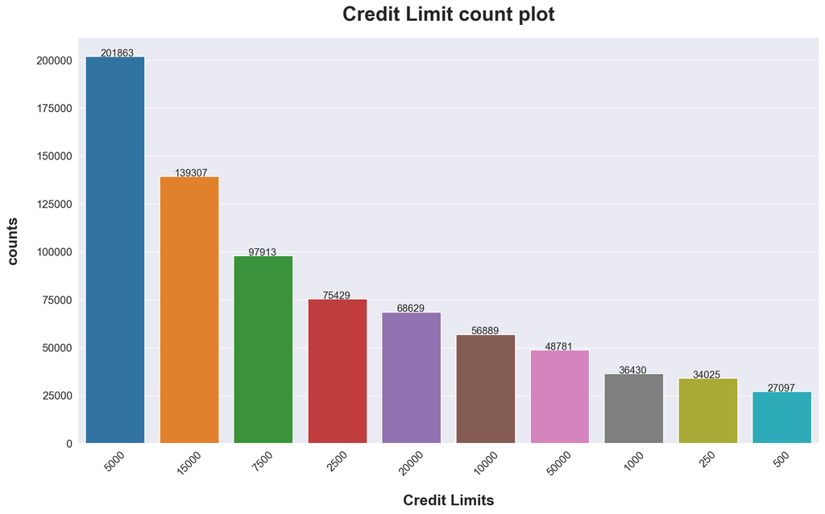

```python
plot_bar(df_num_cols,'creditLimit',"Credit Limits","counts","Credit Limit count plot")
```

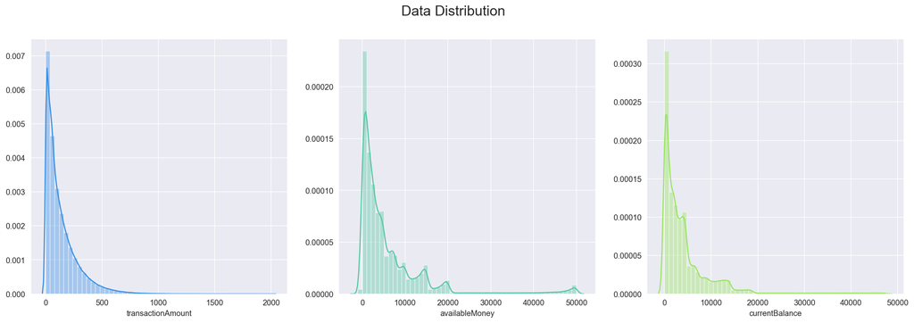

```python
# Check availableMoney & currentBalance columns

fig, ax = plt.subplots(nrows=1, ncols=3, figsize=(20,6))
n_cols = ['transactionAmount','availableMoney', 'currentBalance']
colors = ['#3C91E6','#59C9A5','#9BE564']
counter = 0

for j in range(3):
    sns.distplot(df_num_cols[n_cols[counter]], ax=ax[j], color=colors[j])
    ax[j].set_xlabel(n_cols[counter], fontsize=10)
    ax[j].set_ylabel('')
    counter+=1

fig.suptitle('Data Distribution', fontsize=18)
```

- *The data distribution for availablemoney & currentbalance is skewed to the right which kinda makes sense as we saw* *that most of the credit limit are between 5000 USD - 15,000 USD*
- *available money can be negative (min value -1005.6) as well which can mean overdraft happened*
- *currentBalance has zero values (min value 0) which can mean that the balance has been paid off*
- *Transaction amount has several 0 USD transaction and the mean transaction is 137 USD - usually transactions happen in smaller amounts*

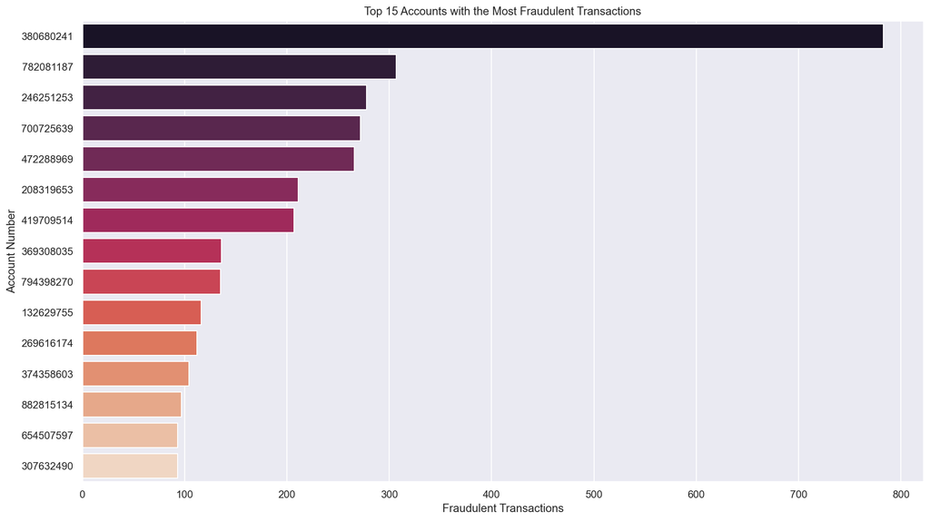

```python
# plot graph of Top 10 Accounts with most Fraudulent Transactions
clients = df[df['isFraud'] == True]
sns.set(rc={'figure.figsize':(16,9)})
top15= clients['accountNumber'].value_counts().head(15)
sns.barplot(y=list(range(15)), x=top15.values,palette="rocket", orient='h')
plt.title('Top 15 Accounts with the Most Fraudulent Transactions')
plt.xlabel('Fraudulent Transactions')
plt.yticks(ticks=list(range(15)), labels=top15.index.tolist())
plt.ylabel('Account Number')
```

- *Account 380680241 has the most fraudulent transactions*

### Summary Stats & Observations for boolean dtype columns

```python
df_bool_cols.columns
```

```
Index(['cardPresent', 'expirationDateKeyInMatch', 'isFraud'], dtype='object')
```

```python
# Checking value counts of cardPresent

df_bool_cols.cardPresent.value_counts()
```

```
False    433495
True     352868
Name: cardPresent, dtype: int64
```

```python
round(df_bool_cols.cardPresent.value_counts()[0]/len(df_bool_cols),4)
```

```
0.5513
```

- *Online transactions accounted for 55% of all transactions.*

```python
# Distribution of fraud vs non-fraud cases

df_bool_cols['isFraud'].value_counts()
```

```
False    773946
True      12417
Name: isFraud, dtype: int64
```

```python
df_bool_cols.isFraud.value_counts(normalize=True)
```

```
False    0.98421
True     0.01579
Name: isFraud, dtype: float64
```

```python
# Calculate total money lost in Fraudulent transactions

df.query("isFraud == True")['transactionAmount'].sum()
```

```
2796505.89
```

- *isFraud" is our Target variable*
- *There are 12417 fraudulent cases among all transactions.*
- *Ratio of fraudulent cases to all transactions is 1.5%.So the dataset is highly imbalanced.*
- *Total dollar estimate lost in Fraudulent transactions: 2,796,505.89 USD*

### Summary Stats & Observations for datetime dtype columns

```python
df_date_cols.columns
```

```
Index(['transactionDateTime', 'currentExpDate', 'accountOpenDate',
       'dateOfLastAddressChange'],
      dtype='object')
```

```python
# Check the min & max date values

print('Max Date value in -')
for col in df_date_cols.columns:
    print(col+':  '+str(df_date_cols[col].max()))
print('\n')
print('Min Date value in -')
for col in df_date_cols.columns:
    print(col+':  '+str(df_date_cols[col].min()))
```

```
Max Date value in -
transactionDateTime:  2016-12-30 23:59:45
currentExpDate:  2033-08-01 00:00:00
accountOpenDate:  2015-12-31 00:00:00
dateOfLastAddressChange:  2016-12-30 00:00:00


Min Date value in -
transactionDateTime:  2016-01-01 00:01:02
currentExpDate:  2019-12-01 00:00:00
accountOpenDate:  1989-08-22 00:00:00
dateOfLastAddressChange:  1989-08-22 00:00:00
```

*So the tranasctions in the datset are from the year 2016*

### Summary Stats & Observations for object dtype columns

```python
df_obj_cols.columns
```

```
Index(['merchantName', 'acqCountry', 'merchantCountryCode', 'posEntryMode',
       'posConditionCode', 'merchantCategoryCode', 'transactionType'],
      dtype='object')
```

```python
# Check merchantCategoryCode columns

len(df_obj_cols.merchantCategoryCode.unique())
```

```
19
```

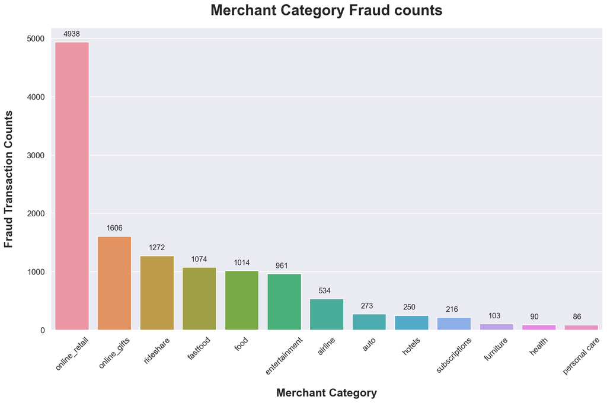

```python
# Plot graph for Merch category counts for all fraud transactions

plot_bar(df[df['isFraud'] == True],'merchantCategoryCode',"Merchant Category","Fraud Transaction Counts","Merchant Category Fraud counts")
```

- *There are 19 merchant categories*
- *Top 3 categories are online, fastfood and entertainment in terms of the number of transactions.*
- *Online retails, gifts, rideshare and food category has most number of fraudulant transactions*

```python
# Check other columns

for col in ['acqCountry', 'merchantCountryCode', 'posEntryMode','posConditionCode']:
    print(df_obj_cols[col].value_counts())
    print('------------------------------------------------------------------------')
```

```
US     774709
         4562
MEX      3130
CAN      2424
PR       1538
Name: acqCountry, dtype: int64
------------------------------------------------------------------------
US     778511
MEX      3143
CAN      2426
PR       1559
          724
Name: merchantCountryCode, dtype: int64
------------------------------------------------------------------------
05    315035
09    236481
02    195934
90     19576
80     15283
        4054
Name: posEntryMode, dtype: int64
------------------------------------------------------------------------
01    628787
08    149634
99      7533
         409
Name: posConditionCode, dtype: int64
------------------------------------------------------------------------
```

- *The dataset includes transactions in 4 countries US, Canada, Mexico and Puerto Rico.*

```python
# Check the transactionType column
df_obj_cols['transactionType'].value_counts()
```

```
PURCHASE                745193
REVERSAL                 20303
ADDRESS_VERIFICATION     20169
                           698
Name: transactionType, dtype: int64
```

- *There are 3 transaction types Purchase, Reversal & Address verification*

```python
# Check the merchantName column

# Clean up the junk values
df_obj_cols["merchantName"] = df_obj_cols.merchantName.str.replace(r"\s#.*$", "", regex=True)

#Check the unique merchantName
len(df_obj_cols.merchantName.unique())
```

```
205
```

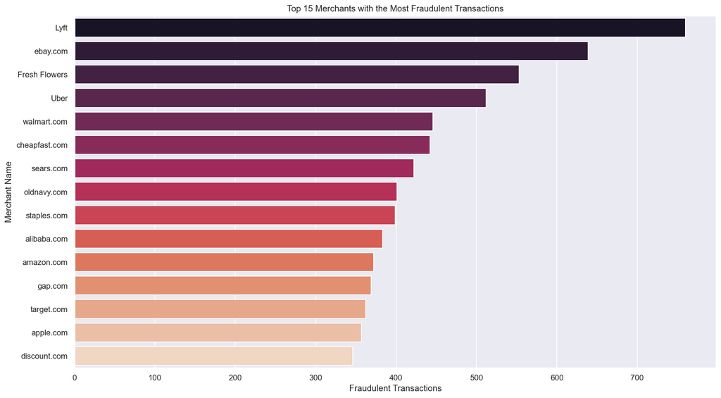

```python
# Plot graph of Top 10 merchants with most Fraudulent transactions

clients = df[df['isFraud'] == True]
sns.set(rc={'figure.figsize':(16,9)})
top15= clients['merchantName'].value_counts().head(15)
sns.barplot(y=list(range(15)), x=top15.values,palette="rocket", orient='h')
plt.title('Top 15 Merchants with the Most Fraudulent Transactions')
plt.xlabel('Fraudulent Transactions')
plt.yticks(ticks=list(range(15)), labels=top15.index.tolist())
plt.ylabel('Merchant Name')
```

*Top 5 Merchants with highest number of fraudulent transactions are as follows:*

1. Lyft
2. Ebay.com
3. Fresh Flowers
4. Uber.com
5. Walmart.com

*This is noted as it can be used during feature engineering as a feature*

# Question 2: Plot

## 2.1 Plot a histogram of the processed amounts of each transaction, the transactionAmount column.

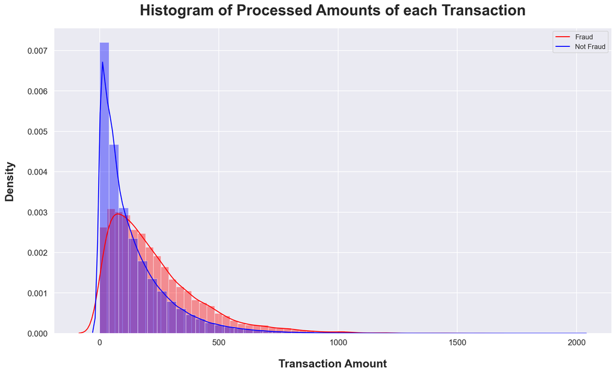

```python
fig, (axis1) = plt.subplots(1,1,figsize=(16,9))
sns.distplot(df[df.isFraud==True].transactionAmount, bins=50,color='red' )
sns.distplot(df[df.isFraud==False].transactionAmount, bins=50,color='blue')
plt.legend(labels=['Fraud', 'Not Fraud'])
plt.xlabel('Transaction Amount',fontdict= {'fontsize': 18,'fontweight':'bold'},labelpad=20)
plt.ylabel('Density',fontdict= {'fontsize': 18,'fontweight':'bold'},labelpad=20)
plt.title("Histogram of Processed Amounts of each Transaction",fontdict= { 'fontsize': 24, 'fontweight':'bold'},pad=20)
plt.xticks(fontsize=13)
plt.yticks(fontsize=13)
plt.show()
```

## 2.2 Report any structure you find and any hypotheses you have about that structure.

```python
df.query("transactionAmount==0").transactionType.value_counts()
```

```
ADDRESS_VERIFICATION    20169
PURCHASE                 1484
REVERSAL                  572
Name: transactionType, dtype: int64
```

```python
df.query("transactionAmount==0").transactionType.value_counts(normalize=True)
```

```
ADDRESS_VERIFICATION    0.907492
PURCHASE                0.066772
REVERSAL                0.025737
Name: transactionType, dtype: float64
```

- One interesting structure I found in fraudulent transactions is that the peak is at about 100 dollars while the peak of non-fraudulent transactions is at about 10 dollars. This indicates that normal transactions are more likely to occur in small amount while fraudulent transactions tend to aim for a higher amount.
- The Transaction amount shows a non-symmetric distribution.
- It is skewed to the right (positive skewed) due to fact that there are several 0 USD transactions and usually low amount value transactions are more frequent than large value transactions.
- Intrestingly, the number of observations where transaction amount is zero is almost 91% when transaction type is Address verification.
- Upon reading more about it - Perhaps the 0 USD transaction are temporary charges for address verifications

# Question 3: Data Wrangling - Duplicate Transactions

You will notice a number of what look like duplicated transactions in the data set. One type of duplicated transaction is a reversed transaction, where a purchase is followed by a reversal. Another example is a multi-swipe, where a vendor accidentally charges a customer's card multiple times within a short time span.

## 3.1 Can you programmatically identify reversed and multi-swipe transactions?

```python
# Copying the original dataframe and removing empty string values from few observed columns
df_find_dupe = df.copy(deep=True)

# Dropping rows with empty values (since they are signifiantly lower in number)
df_find_dupe = df_find_dupe[df_find_dupe.transactionType != ""]

#Now lets slice the data from main dataframe for our analysis
df_find_dupe = df_find_dupe[['customerId', 'transactionAmount', 'merchantName','transactionType',
                   'cardLast4Digits', 'cardPresent', 'isFraud', 'transactionDateTime']]
```

### Reversed Transaction

The reversed transactions are mentioned in transactionType column.

```python
print('Number of reversed transaction in the dataset :'+ str(len(df_find_dupe.query('transactionType == "REVERSAL"'))))
```

```
Number of reversed transaction in the dataset :20303
```

- **Assumption**

*Initially I was assuming that all transactionType = REVERSE would fall under the category of being a "duplicated transaction". Reading a bit more about reverse transactions, i realised it's not exactly same as refund transactions, which i had originally assumed. There's a fundamental difference between both which helped in my hypothesis of labeling when we can label a reversed transaction as duplicate*

*A refund occurs when a transaction is posted and the funds are already in the merchantâ€™s account. On the other hand, a reversal occurs when the transaction is halfway through the process; that is, it is yet to post.*

**So, my final understanding is that the duplicate tranasction in our case can be defined as those where transactionType "purchase" is followed by a reversal in a short amount of time since we read just above that reversal occurs when the transaction is halfway through the process**

Source: https://getoutofdebthub.com/difference-between-refund-and-reversal-transaction/

### Multi-Swipe transactions

**Multi-swipe transaction will occur when the same account has a consequent transaction of the same amount in a very small period of time. So, a "purchase" will be followed by another "purchase" transaction.**

### "Short time" Range Calculation

There is no specific threshold of how each bank defines the time length for a transaction to be considered duplicate

So one approach I took is to look at the number of transactions in time slots of 30 seconds which an assumption of upper boundary of 15min because mostly a fraudster would do multiple transactions in short amount of time before the owner realises that they have been duped, so there's a short time of window for a fraudster and that is what i wanted to derive at

```python
# Create a copy of original dataframe for analysis
df_short_time = df_find_dupe.copy(deep=True)

# Time difference on seconds between transactions
df_short_time['time_diff_sec'] = (df_short_time.transactionDateTime - df_short_time.transactionDateTime.shift(1)).astype('timedelta64[s]')

# Similar Account
df_short_time['same_account'] = df_short_time.customerId - df_short_time.customerId.shift(1)

# Transactions that happened under 15 min for same customer
df_trans_15 = df_short_time[(df_short_time['time_diff_sec']<=1800) & (df_short_time['time_diff_sec']>0) & (df_short_time['same_account']==0)]
```

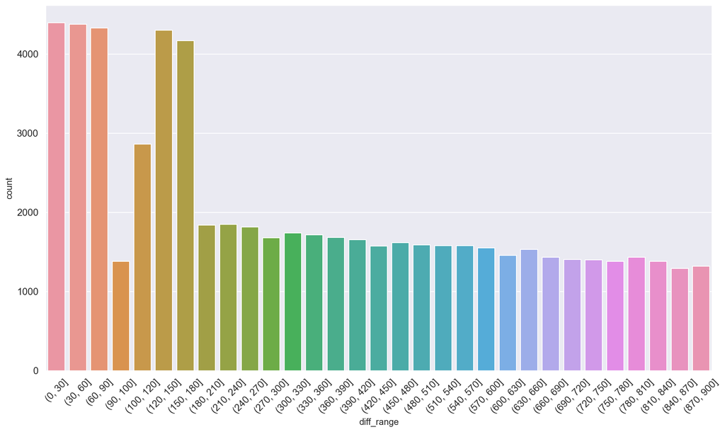

```python
# Plot graph for frequency of transactions broken down by the time slots of 30 seconds

fig, (axis1) = plt.subplots(1,1,figsize=(16,9))
df_trans_15['diff_range'] = pd.cut(df_trans_15["time_diff_sec"], [0,30,60,90,100,120,150,180,210,240,270,300,330,
                                                                 360,390,420,450,480,510,540,570,600,630,660,690,
                                                                 720,750,780,810,840,870,900])
sns.countplot(x="diff_range", data=df_trans_15)
plt.xticks(fontsize=13,rotation=45)
plt.yticks(fontsize=13)
plt.show()
```

- **Assumption** (based on analysis)

*We can observe a pattern here. The number of transactions fluctuates a lot in the first 180 seconds after that it becomes very flat. Based on this pattern, I choose 180 seconds as the threshold of "Short Time Range" to derive duplicates*

**Final logic to calculate duplicate transaction**

So, putting all the pieces together. Following are the steps to calculate duplicate transactions-

1. Group the transactions by Account Number, Merchant Name, Transaction Amount and cardLast4Digits
2. Sort by transaction date
3. Compute the time difference between each of the subsequent requests (in seconds)
4. Flag all the transactions that have a time gap of less than 3 min/180 secs (threshold picked based on analysis)
5. Pick the transaction with flagged value as True

Note: This logic will automatically label the first transaction to be "normal" and exclude it from the duplicate transaction thus meeting the criteria of the question

```python
# Applying the above mentioned logic
# Creating a flag dupe_trans which means a flag to check if the transaction is duplicate or not

df_find_dupe['dupe_trans'] = (df_find_dupe.sort_values(['transactionDateTime'])
                       .groupby(['customerId', 'transactionAmount','merchantName','cardLast4Digits'], sort=False)['transactionDateTime']
                       .diff()
                       .dt.total_seconds()
                       .lt(181))
```

```python
df_dupe_trans = df_find_dupe.query('dupe_trans==True')
df_dupe_trans
```

|  | customerId | transactionAmount | merchantName | transactionType | cardLast4Digits | cardPresent | isFraud | transactionDateTime | dupe_trans |
| --- | --- | --- | --- | --- | --- | --- | --- | --- | --- |
| 39 | 574788567 | 215.13 | Convenient Tire | REVERSAL | 8522 | True | False | 2016-05-24 01:38:03 | True |
| 133 | 984504651 | 450.74 | Planet Fitness #849960 | REVERSAL | 8332 | False | False | 2016-01-16 09:53:15 | True |
| 200 | 984504651 | 34.92 | Golds Gym #747443 | REVERSAL | 8332 | False | False | 2016-02-12 05:10:49 | True |
| 263 | 984504651 | 118.52 | AMC #706324 | PURCHASE | 8332 | True | False | 2016-03-12 06:34:29 | True |
| 264 | 984504651 | 118.52 | AMC #706324 | PURCHASE | 8332 | True | False | 2016-03-12 06:36:41 | True |
| ... | ... | ... | ... | ... | ... | ... | ... | ... | ... |
| 785983 | 205026043 | 391.94 | Uber | PURCHASE | 3931 | False | False | 2016-06-07 22:29:11 | True |
| 785984 | 205026043 | 391.94 | Uber | PURCHASE | 3931 | False | False | 2016-06-07 22:30:57 | True |
| 786014 | 205026043 | 56.26 | Lyft | REVERSAL | 258 | False | False | 2016-09-18 06:08:02 | True |
| 786120 | 638498773 | 201.79 | KFC #928167 | REVERSAL | 321 | True | False | 2016-01-01 19:48:03 | True |
| 786233 | 638498773 | 390.98 | Krispy Kreme #653472 | PURCHASE | 321 | True | False | 2016-11-29 23:12:01 | True |

13386 rows × 9 columns

- **Reversal Transaction example** (Purchase followed by reversal)

```python
df_find_dupe.query("customerId==574788567 and transactionAmount==215.13")
```

|  | customerId | transactionAmount | merchantName | transactionType | cardLast4Digits | cardPresent | isFraud | transactionDateTime | dupe_trans |
| --- | --- | --- | --- | --- | --- | --- | --- | --- | --- |
| 38 | 574788567 | 215.13 | Convenient Tire | PURCHASE | 8522 | True | False | 2016-05-24 01:35:33 | False |
| 39 | 574788567 | 215.13 | Convenient Tire | REVERSAL | 8522 | True | False | 2016-05-24 01:38:03 | True |

- **Multi-Swipe Transaction example** (Purchase followed by another purchase)

```python
df_find_dupe.query("customerId==205026043 and transactionAmount==391.94")
```

|  | customerId | transactionAmount | merchantName | transactionType | cardLast4Digits | cardPresent | isFraud | transactionDateTime | dupe_trans |
| --- | --- | --- | --- | --- | --- | --- | --- | --- | --- |
| 785982 | 205026043 | 391.94 | Uber | PURCHASE | 3931 | False | False | 2016-06-07 22:27:35 | False |
| 785983 | 205026043 | 391.94 | Uber | PURCHASE | 3931 | False | False | 2016-06-07 22:29:11 | True |
| 785984 | 205026043 | 391.94 | Uber | PURCHASE | 3931 | False | False | 2016-06-07 22:30:57 | True |

## 3.2 What total number of transactions and total dollar amount do you estimate for the reversed transactions? For the multi-swipe transactions? (please consider the first transaction to be "normal" and exclude it from the number of transaction and dollar amount counts)

```python
# No. of duplicate transactions
len(df_dupe_trans)
```

```
13386
```

```python
# No. of duplicate transactions by transactionType
df_dupe_trans.transactionType.value_counts()
```

```
PURCHASE                7449
REVERSAL                5715
ADDRESS_VERIFICATION     222
Name: transactionType, dtype: int64
```

```python
# Total dollar amount for reversed transaction
df_dupe_trans.query('transactionType == "REVERSAL"')['transactionAmount'].sum()
```

```
828777.42
```

```python
# Total dollar amount for Multi-swipe transaction
df_dupe_trans.query('transactionType == "PURCHASE"')['transactionAmount'].sum()
```

```
1102920.9899999998
```

**Reversed Transactions**

- Total number: 5715
- Total dollar amount: $828,777.42

**Multi-swipe Transactions**

- Total number: 7449
- Total dollar amount: $1,102,920.99

**Total duplicate transactions** (according to defined logic): 13386

**Note:** The logic will automatically label the first transaction to be "normal" and exclude it from the duplicate transaction thus meeting the criteria of the question

## 3.3 Did you find anything interesting about either kind of transaction?

```python
df_dupe_all = pd.merge(df, df_dupe_trans, how='inner', on=['customerId','transactionAmount','merchantName','transactionType','cardLast4Digits','cardPresent','isFraud','transactionDateTime'])
```

```python
# Check to see $0 transaction amounts

q1 = """Select transactionType, count(*)
        from df_dupe_all
        where transactionAmount = 0
        group by 1;"""

print(ps.sqldf(q1, locals()))
```

```
        transactionType  count(*)
0  ADDRESS_VERIFICATION       222
1              REVERSAL       180
```

```python
# Check purchase transactions with 0 USD
q1 = """Select count(*)
        from df
        where transactionType="PURCHASE" and transactionAmount = 0
        """

print(ps.sqldf(q1, locals()))
```

```
   count(*)
0      1484
```

```python
# No. of duplicate transactions by transactionType
df_dupe_all.transactionType.value_counts()
```

```
PURCHASE                7449
REVERSAL                5715
ADDRESS_VERIFICATION     222
Name: transactionType, dtype: int64
```

- *180 duplicate reversal transactions have 0 USD associated to it and there are 1484 purchase transactions with 0 USD so there are 180 purchase transactions out of 1484 which are have a reversal duplicate. Would be interesting to know what the rest 1304 transactions with 0 USD are all about.*
- *All duplicated address_verification transactions have 0 USD amount associated to it.*

```python
q1 = """Select count(*)
        from df_dupe_all
        where transactionType="PURCHASE" and isFraud = True
        """

print(ps.sqldf(q1, locals()))
```

```
   count(*)
0       129
```

```python
q1 = """Select count(*)
        from df_dupe_all
        where transactionType="REVERSAL" and isFraud = True
        """

print(ps.sqldf(q1, locals()))
```

```
   count(*)
0       103
```

*1.73% of flagged duplicate multi-swipe transactions are labelled fraud and 1.8% of flagged duplicate reversal transactions are labelled fraud*

```python
# Multi-swipe transactions by merchant category

q1 = """Select merchantCategoryCode,count(*)
        from df_dupe_all
        where transactionType = "PURCHASE" and isFraud= True
        group by 1
        order by 2 desc
        """

print(ps.sqldf(q1, locals()))
```

```
   merchantCategoryCode  count(*)
0         online_retail        51
1              fastfood        17
2         entertainment        14
3          online_gifts        13
4             rideshare        11
5                  food         8
6               airline         7
7         personal care         2
8                hotels         2
9                  auto         2
10        subscriptions         1
11            furniture         1
```

*online_retail, fastfood, entertainment, online-gifts categories have the most fraudulent multi-swipe transactions*

```python
# Reversal transactions by merchant category

q1 = """Select merchantCategoryCode,count(*)
        from df_dupe_all
        where transactionType = "REVERSAL" and isFraud= True
        group by 1
        order by 2 desc
        """

print(ps.sqldf(q1, locals()))
```

```
   merchantCategoryCode  count(*)
0         online_retail        36
1          online_gifts        15
2             rideshare        13
3                  food        10
4              fastfood         8
5         entertainment         8
6               airline         5
7                  auto         4
8         personal care         2
9                hotels         1
10            furniture         1
```

*online_retail, online_gifts, rideshare, food merchant categories have the most fraudulent reversed transactions*

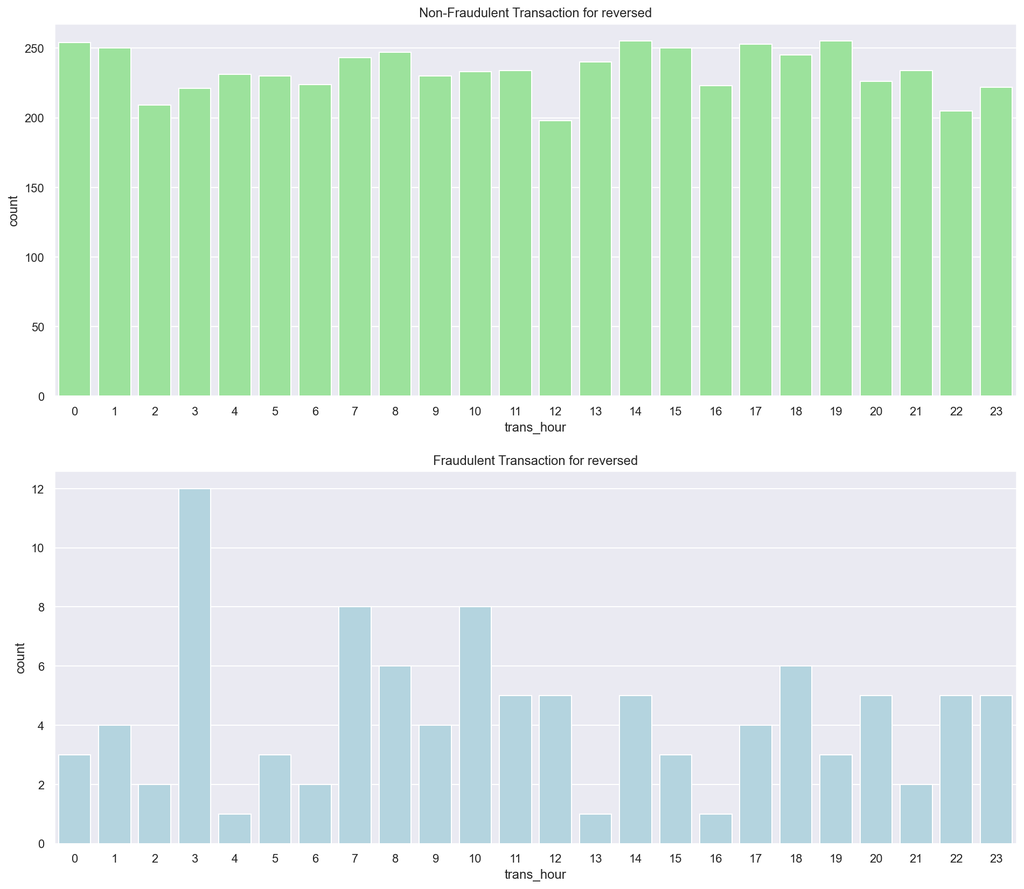

```python
# For Reversed Transactions

rev_trans = df_dupe_all[df_dupe_all.transactionType=="REVERSAL"]

rev_trans['trans_hour'] = rev_trans['transactionDateTime'].dt.hour
fig, axes = plt.subplots(2, 1, figsize=(16,14))

sns.countplot(
    x="trans_hour",
    data=rev_trans[rev_trans['isFraud'] == False],
    color="lightgreen",
    ax=axes[0])
axes[0].set_title("Non-Fraudulent Transaction for reversed")


sns.countplot(
    x="trans_hour",
    data = rev_trans[rev_trans['isFraud'] == True],
    color="lightblue",
    ax=axes[1])
axes[1].set_title("Fraudulent Transaction for reversed")
```

*Non-fraudulent reversed transactions are distributed throughout the day while fraudulent reversed transactions show a peak at 3am followed by 7am & 10am*

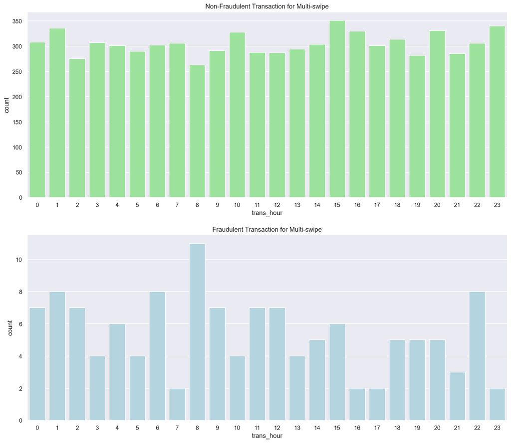

```python
# For Multi-swipe Transactions

mul_trans = df_dupe_all[df_dupe_all.transactionType=="PURCHASE"]

mul_trans['trans_hour'] = mul_trans['transactionDateTime'].dt.hour
fig, axes = plt.subplots(2, 1, figsize=(16,14))

sns.countplot(
    x="trans_hour",
    data=mul_trans[mul_trans['isFraud'] == False],
    color="lightgreen",
    ax=axes[0])
axes[0].set_title("Non-Fraudulent Transaction for Multi-swipe")


sns.countplot(
    x="trans_hour",
    data = mul_trans[mul_trans['isFraud'] == True],
    color="lightblue",
    ax=axes[1])
axes[1].set_title("Fraudulent Transaction for Multi-swipe")
```

*Non-fraud multi-swipe transactions are distributed throughout the day while fraudulent multi-swipe transactions show a peak at 8am followed by 6am & 10pm*

**Summary of Interesting Observations**

- 180 duplicate reversal transactions have 0 USD associated to it and there are 1484 purchase transactions with 0 USD. so there are 180 purchase transactions out of 1484 which are have a reversal duplicate. Would be interesting to know what the rest 1304 transactions with 0 USD are all about.
- All duplicated address_verification transactions have 0 USD amount associated to it.
- online_retail, online_gifts, rideshare, food merchant categories have the most fraudulent reversed transactions
- online_retail, fastfood, entertainment, online-gifts categories have the most fraudulent multi-swipe transactions
- Non-fraudulent reversed transactions are distributed throughout the day while fraudulent reversed transactions show a peak at 3am followed by 7am & 10am
- Non-fraud multi-swipe transactions are distributed throughout the day while fraudulent multi-swipe transactions show a peak at 8am followed by 6am & 10pm
- We see that most of the fraudulent activites reach peak during early morning times
- 1.73% of flagged duplicate multi-swipe transactions are labelled fraud and 1.8% of flagged duplicate reversal transactions are labelled fraud

# Question 4: Model

Fraud is a problem for any bank. Fraud can take many forms, whether it is someone stealing a single credit card, to large batches of stolen credit card numbers being used on the web, or even a mass compromise of credit card numbers stolen from a merchant via tools like credit card skimming devices.

- Each of the transactions in the dataset has a field called isFraud. Please build a predictive model to determine whether a given transaction will be fraudulent or not. Use as much of the data as you like (or all of it).
- Provide an estimate of performance using an appropriate sample, and show your work.
- Please explain your methodology (modeling algorithm/method used and why, what features/data you found useful, what questions you have, and what you would do next with more time)

**Table of contents**

**1. Feature Engineering**  
*Reasoning behind making new features.*

**2. How to tackle Imbalanced data**  
*Different techniques to keep in mind while working with imbalanced data which i will be incorporating in my work.*

**3. Interpreting the problem & Trade-offs**  
*Benchmarks for defining solution to our problem and assumptions I am taking along with the questions I have.*

**4. Evaluation Metrics used**  
*Different set of evaluation metrics I am using to make sense of my model.*

**5. Modeling Algorithm & estimate of performance**  
*Different approaches i tried out and interpreting their results.*

**6. Avoiding Data Leaks**  
*Summary of set of steps which I incorporated through the modeling phase to avoid data leaks.*

**7. Appendix**  
*Other approaches i tried but not including in the main modeling section*

**8. Future work**  
*Approaches i would have tried out if i had more time & much better computational power at my disposal.*

**9. References**

```python
df_new = df.copy(deep=True)
```

```python
# Dropping rows with empty values (since they are signifiantly lower in number)
df_new = df_new[df_new.acqCountry != ""]
df_new = df_new[df_new.merchantCountryCode != ""]
df_new = df_new[df_new.posEntryMode != ""]
df_new = df_new[df_new.posConditionCode != ""]
df_new = df_new[df_new.transactionType != ""]
```

## 1. Feature Engineering

Feature engg is the most important. This will involve building new features and encoding the existing one. I have provided the resoning behind deriving those features

### Building new Features

#### Date-Time Features

Breaking down transaction month, day, week, hour as a feature-  
*helpful in learning a pattern as to see fraud event frequency - a specific time, a particular day, weekend/weekday to do transaction*

1. trans_month
2. trans_day_of_month
3. trans_day_of_week
4. trans_hour
5. time_of_day
6. weekday
1. since_days_lastAddressChange  
   Days since last address change - *helpful in learning patterns of fraudster who changes address before committing a fraud: identity theft*

```python
# Converting date columns to date time

df_new.transactionDateTime = pd.to_datetime(df_new.transactionDateTime)
df_new.currentExpDate = pd.to_datetime(df_new.currentExpDate)
df_new.accountOpenDate = pd.to_datetime(df_new.accountOpenDate)
df_new.dateOfLastAddressChange = pd.to_datetime(df_new.dateOfLastAddressChange)
```

```python
df_new["trans_month"] = df_new.transactionDateTime.dt.month                 #transaction month
df_new["trans_day_of_month"] = df_new.transactionDateTime.dt.day            #transaction day of month
df_new["trans_day_of_week"] = df_new.transactionDateTime.dt.dayofweek       #transaction day of week
df_new["trans_hour"] = df_new.transactionDateTime.dt.hour                   #transaction hour

# Time of the day
# Divided the day into 4 timings essentially: morning, afternoon, evening, night
df_new["time_of_day"] = pd.cut(df_new.trans_hour, bins=4, labels=['Morning', 'afternoon', 'evening', 'night'])

# Weekday/Weekend flag
df_new["weekday"] = df_new.trans_day_of_week < 5

# Days since last address change
df_new["since_days_lastAddressChange"] = (df_new.transactionDateTime - df_new.dateOfLastAddressChange).dt.days
```

#### Credit limit, Balance and Transaction related Features

1.cred_limit_used%  
Credit limit utilization - *it reflects the customers credit behaviour*

2.trans_amt_cred%  
Transaction amount as % of credit limit - *it shows purchasing pattern*

3.trans_amt_availmoney%  
Transaction amount as % of available money - *it shows credit behaviour*

```python
# Credit limit utilization, tranaction to limit and trans amount-available money ratio

df_new['cred_limit_used%'] = np.where(
    df_new['creditLimit'] != 0, df_new['currentBalance']/df_new['creditLimit']*100, 0)

df_new['trans_amt_cred%'] = np.where(
    df_new['creditLimit'] != 0, df_new['transactionAmount']/df_new['creditLimit']*100, 0)

df_new['trans_amt_availmoney%'] = np.where(
    df_new['availableMoney'] != 0, df_new['transactionAmount']/df_new['availableMoney']*100, 0)
```

#### Age of the account

- account_age

```python
df_new["account_age"] = (df_new.transactionDateTime - df_new.accountOpenDate).dt.days
```

#### Code matching Features

1. cvv_matched  
   if cardCVV is same as enteredCVV - *feature to learn/flag potential fraud events*
1. country_code_match  
   if acqcountry code matches with the merchantcode

```python
# cardCVV same as enteredCVV
df_new["cvv_matched"] = df_new.cardCVV == df_new.enteredCVV

# Country code match
df_new["country_code_match"] = df_new.acqCountry == df_new.merchantCountryCode
```

#### Average fraud of customer/account

- avg_fraud: *This would be helpful if getting an idea about the average fraud of the customer/account before the next transaction*

```python
# Shifting down by one and expanding to calculate average fraud for each customer
df_new["avg_fraud"] = (
    df.groupby("customerId")["isFraud"]
    .apply(lambda x: x.shift(1).expanding().mean())
    .fillna(0)
)
```

#### Transaction related Features

*These feature will tell us spending patterns of a customer. If here is unusual high transaction than average over a spand of a day or over a month then it can help out in detecting a fraudulent transaction*

1.total_spent_one_day  
Total amount spent each day by Customer

2.avg_spent_month  
Average Amount spent per transaction over in a month by Customer

3.time_diff_perTrans  
Minimum time (in min) between transactions in a 30 day span

4.diff_country_three_min  
Transactions that happen in separate countries, but minutes apart  
*This would be helpful in detecting fraudulent activities as transactions that happen over a short span of time (earlier we figured the threshold of 3 min) across different countries have high potential of being a fraud*

```python
# Total amount spent each day
df_new["total_spent_one_day"] = (
    df_new.groupby("customerId")
    .apply(
        lambda x: x.rolling("1D", on="transactionDateTime")["transactionAmount"].sum()
    )
    .reset_index("customerId")
    .drop("customerId", axis=1)
    .sort_index()
    .squeeze()
)

# average amount spent per transaction over a span of a month
df_new["avg_spent_month"] = (
    df_new.groupby("customerId")
    .apply(
        lambda x: x.rolling("30D", on="transactionDateTime")["transactionAmount"].mean()
    )
    .reset_index("customerId")
    .drop("customerId", axis=1)
    .sort_index()
    .squeeze()
)
```

```python
# Minimum time (in minutes) between transactions in a 30 day span

# Step 1 Difference in time per group
df_new["time_diff_perTrans"] = (
    df_new.groupby("customerId")["transactionDateTime"].diff().fillna(pd.Timedelta(0))
)
df_new["time_diff_perTrans"] = (df_new.time_diff_perTrans.dt.total_seconds() / 60).astype("int")

# Step 2 Calculate min time diff
df_new["min_time_diff_month"] = (
    df_new.groupby("customerId")
    .apply(lambda x: x.rolling("30D", on="transactionDateTime")["time_diff_perTrans"].min())
    .reset_index("customerId")
    .drop("customerId", axis=1)
    .sort_index()
    .squeeze()
)
```

```python
# Transactions that happen in separate countries, but minutes apart

df_new["trans_time_shift_down1"] = df_new.groupby("customerId").transactionDateTime.shift(1)
df_new["country_shift_down1"] = df_new.groupby("customerId").acqCountry.shift(1)
ctry_diff = df_new.acqCountry != df_new.country_shift_down1
in_window = (df_new.transactionDateTime - df_new.trans_time_shift_down1) < pd.Timedelta("3 minutes")
df_new["diff_country_three_min"] = (ctry_diff & in_window).fillna(False)
```

#### Highly fraudulent merchant category

- merch_risky

We saw earlier the merchants with high number of fraud cases. Since there are 2490 unique merchants, we can use this feature to reduce the dimensions of the merchant column instead of encoding it or dropping it all together. I combined top 25 merchants with high average of fraud. Intution behind taking average/mean is that it's more robut to outliers

```python
# Clean up the # values
df_new["merchantName"] = df_new.merchantName.str.replace(r"\s#.*$", "", regex=True)

#Check the unique merchantName
print('merchant names reducted to '+str(len(df_new.merchantName.unique())))
```

```
merchant names reducted to 205
```

```python
# get top 25 risky merch
top25_risky_merch = list(df_new.groupby(
    ['merchantName']).isFraud.mean().sort_values(ascending=False)[:25].index)

# column that flags risky merch
df_new["merch_risky"] = df_new["merchantName"].isin(top25_risky_merch)
```

### Merchant category code remapping

Data Preprocessing

There are 19 Merch category codes and i reduced them by reclassifying them into 7 categories,which are online, food, travel, phone, health, entertainment and other as it made sense.

```python
df_new['merchantCategoryCode'] = df_new['merchantCategoryCode'].replace({'online_retail': 'online', 'fastfood': 'food', 'food': 'food', 'online_gifts': 'online',
                                                                         'rideshare': 'travel', 'hotels': 'travel', 'fuel': 'travel', 'subscriptions': 'other', 'auto': 'travel', 'health': 'health', 'personal care': 'health',
                                                                         'mobileapps': 'phone', 'airline': 'travel', 'online_subscriptions': 'online', 'furniture': 'other', 'food_delivery': 'food', 'gym': 'health', 'cable/phone': 'phone'})
```

### Bool to Int encoding

Converting Boolean Values to int

- cardPresent
- expirationDateKeyInMatch
- isFraud
- cvv_matched
- country_code_match
- weekday
- diff_country_three_min
- merch_risky

```python
boolean_encode = [
    "cardPresent",
    "expirationDateKeyInMatch",
    "isFraud",
    "cvv_matched",
    "country_code_match",
    "weekday",
    "diff_country_three_min",
    "merch_risky"
]

df_new[boolean_encode] = df_new[boolean_encode].astype("int")
```

**Dropping columns of less significance**

```python
df_new = df_new.drop(
    [
        "accountNumber",                     #new
        "customerId",                     #new
        "transactionDateTime",
        "currentExpDate",
        "accountOpenDate",
        "dateOfLastAddressChange",
        "cardCVV",
        "enteredCVV",
        "cardLast4Digits",
        "trans_time_shift_down1",
        "country_shift_down1",
        "merchantName",
        "availableMoney",
        "currentBalance",
        "time_diff_perTrans",
        "acqCountry",
        "merchantCountryCode"

    ],
    axis=1,
)
```

```python
df_new.shape
```

```
(776668, 28)
```

```python
df_new.head()
```

|  | creditLimit | transactionAmount | posEntryMode | posConditionCode | merchantCategoryCode | transactionType | cardPresent | expirationDateKeyInMatch | isFraud | trans_month | trans_day_of_month | trans_day_of_week | trans_hour | time_of_day | weekday | since_days_lastAddressChange | cred_limit_used% | trans_amt_cred% | trans_amt_availmoney% | account_age | cvv_matched | country_code_match | avg_fraud | total_spent_one_day | avg_spent_month | min_time_diff_month | diff_country_three_min | merch_risky |
| --- | --- | --- | --- | --- | --- | --- | --- | --- | --- | --- | --- | --- | --- | --- | --- | --- | --- | --- | --- | --- | --- | --- | --- | --- | --- | --- | --- | --- |
| 0 | 5000 | 98.55 | 02 | 01 | travel | PURCHASE | 0 | 0 | 0 | 8 | 13 | 5 | 14 | evening | 0 | 518 | 0.0 | 1.9710 | 1.9710 | 518 | 1 | 1 | 0.0 | 98.55 | 98.55 | 0.0 | 0 | 0 |
| 1 | 5000 | 74.51 | 09 | 01 | entertainment | PURCHASE | 1 | 0 | 0 | 10 | 11 | 1 | 5 | Morning | 1 | 577 | 0.0 | 1.4902 | 1.4902 | 577 | 1 | 1 | 0.0 | 74.51 | 74.51 | 84398.0 | 0 | 0 |
| 2 | 5000 | 7.47 | 09 | 01 | phone | PURCHASE | 0 | 0 | 0 | 11 | 8 | 1 | 9 | afternoon | 1 | 605 | 0.0 | 0.1494 | 0.1494 | 605 | 1 | 1 | 0.0 | 7.47 | 40.99 | 40572.0 | 0 | 0 |
| 3 | 5000 | 7.47 | 09 | 01 | phone | PURCHASE | 0 | 0 | 0 | 12 | 10 | 5 | 2 | Morning | 0 | 637 | 0.0 | 0.1494 | 0.1494 | 637 | 1 | 1 | 0.0 | 7.47 | 7.47 | 45656.0 | 0 | 0 |
| 4 | 5000 | 71.18 | 02 | 01 | food | PURCHASE | 1 | 0 | 0 | 3 | 24 | 3 | 21 | night | 1 | 231 | 0.0 | 1.4236 | 1.4236 | 231 | 1 | 1 | 0.0 | 71.18 | 71.18 | 0.0 | 0 | 0 |

### Correlation Matrix

```python
#plotting correlations
#corr=df_new.corr(method='spearman')
#plt.figure(figsize=(16, 16))
#mask = np.zeros_like(corr)
#mask[np.triu_indices_from(mask)] = True
#sns.heatmap(corr, xticklabels=corr.columns,yticklabels=corr.columns,cmap="RdBu", annot=True,fmt=".2f", mask=mask,
#    vmax=.2, center=0,square=True,linewidths=1, cbar_kws={"shrink": .5})
```

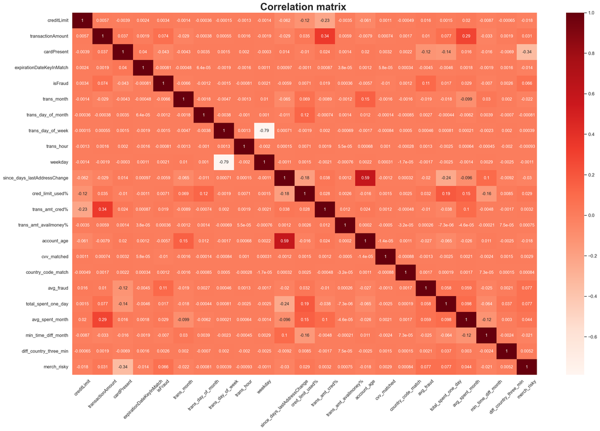

```python
# Check Correlation matrix again (before oneHotencoding)

plt.figure(figsize=(25,16)) # figure ration 16:9
sns.set()
hm = sns.heatmap(df_new.corr(), annot = True,annot_kws={"fontsize":10},cmap=plt.cm.Reds)
plt.title("Correlation matrix ",fontdict= { 'fontsize': 24, 'fontweight':'bold'})
plt.xticks(rotation=45)
plt.show()
```

### One Hot Encoding

- posEntryMode
- posConditionCode
- merchantCategoryCode
- transactionType
- CreditLimit

```python
df_new1=df_new.copy(deep=True)
```

```python
df_new1 = pd.get_dummies(df_new1, columns=['time_of_day',
                            'posEntryMode', 'posConditionCode', 'merchantCategoryCode', 'transactionType','creditLimit'])
```

```python
#Check null
df_new1.isnull().any().any()
```

```
False
```

## 2. How to Tackle Imbalanced Data

```python
# Making a copy of our final data
df_inp = df_new1.copy(deep=True)
```

```python
df_inp.isFraud.value_counts(normalize=True)
```

```
0    0.984593
1    0.015407
Name: isFraud, dtype: float64
```

**1. Resampling Methods**

- Undersampling  
  We create a subset of the original data set by eliminating instances (usually majority class instances).
- Oversampling  
  We create a sub set of the original data set by replicating some instances or creating new instances from existing ones.
- Hybrid  
  Mix of both undersampling & oversampling techniques

  *NOTE: Always split the date into test and train sets BEFORE trying sampling techniques!*

**2. Cross-Validation**

- Using stratified k-fold cross validation would be a good way of approaching this problem,Stratification will ensure that the percentages of each class in our entire data will be the same (or very close to) within each individual fold.

**3. Adjusting class weights/ Cost-Sensitive Training**

- In general, classification models weigh each class equally. we can change the weights of classes so that a misclassification of an observation in a minority class outweighs a misclassification of majority class. In Some algo we cab increase the cost of classification mistakes on the minority class, which would be another right way of approching our problem.

**4. Threshold-Moving for Imbalanced Classification**

How do we choose the threshold on the ROC Curve that results in the best balance between the true positive rate and the false positive rate? (needs business insights)

*Note: Due to time constraints I will only be trying out some of these approaches and not all. Given more time i would like to test all of these approcahes to see what gives us best results*

## 3. Interpreting the problem & Trade-offs

**Trade off**

Now lets forsee the outcomes of our model and it's monetary impact  
Given that, we will have different costs for different predicted outputs.

1.True Positive (TP): the model predicts its a fraud given it is really a fraud, we cancel the transaction correctly, the bank will have no costs or just administration fees.

2.True Negative (TN): the model predicts the transaction is not fraudulent and it actually isn't, the bank will approve it and no costs occur. ($0)

3.False Positive (FP): the model predicts its a fraud given it actually is not fraud, Bank will need to pay for the customer service fee (and potentially the cost of losing a customer).

4.False Negative (FN): the model predicts its a non-fraudulent transaction given it actually is a fraud, bank approve the order wrongly and need to pay for the chargebacks while losing the amount of the order.(example-dependent)

FP: false positives are very harmful because they prevent customers from using their credit cards, repeated FP for a customer may end in potentailly losing the customer  
FN: False negatives are obviously very impactful as it's causing banks loose lot of money.

*So we see, the penalty for mislabeling a fraud transaction as legitimate is having a users money stolen, which the credit card company typically reimburses. On the other hand, the penalty for mislabeling a legitimate transaction as fraud is having the user frozen out of their finances and unable to make payments. There is a very fine **tradeoff** between these two consequences*

**The Question I have?**

Given that the potential costs for FP and FN differ in magnitude from business to business, it's left for the respective organisations to apply relative weights to balance the effect of FP or FN on their businesses.

**For Capital one, in a fraud situation, what is the cost of 1 FN vs 1 FP? or 1FN to 5FP. It's hard to assume for me but i am quite intrigued to know the answer of this !!**

**Assumptions**

Precision and recall numbers depend on the actual probability of fraud in the data. Where high precision relates to a low false positive rate, and high recall relates to a low false negative rate.

- My assumption is that generally fraudulent cases are very small in number so precision might be low, but recall should be high i.e we should try to lower the FN
- Perhaps with sampling techniques the trade-off will change a bit, we will try to increase the TP as well while trying to lower the FP

## 4. Evaluation Metrics

**Choose the correct set of Perfomance evaluation metrics**

Like we saw earlier as well, the data provided is highly imbalanced. So we have to keep in mind when using an evaluation metric to see how good our model is.

- About Accuracy Score: NO

  Using accuracy score as a evaluation metrics for such highly imbalanced dataset is not a good measure of classifier performance.  
  In our data the distribution of majority-to-minority class is 98.5:1.5 then labelling all data points as majority class would give us around 98% accuracy which is really good score in predictive modelling. But in our case the classifier algorithm has not learnt anything about the problem at hand.
- Confusion Matrix

  Confusion matrix will tell us about True positives, True negatives, False positives, False negatives which would be better to evaluate in our case as it will show the inorrect predictions made as well, which will give us much deeper insight to the errors made by model.  
  We can prioritize and tweak/reduce FN (Model predicted not-fraud but actually it was a fraud) and FP ( Model predicted fraud but actually it was a non-fraud) while increasing TP
- AUC-ROC

  The Curve will tell us about how good the model can distinguish between Fradulent & Non-Fraudulent classes. If it's a fraud or not - which is what we want in our case. The more the AUC the better the model is.  
  One thing to keep in mind is the choice of threshold value we choose will also depend on how the classifier is intended to be used.
- Precision/Recall/F1 Score

  *It tells us about the efficiency of the model, how much or data is biased towards one class and us understand whether our model is preforming well in imbalanced dataset for minority class.*
- PR Curve & AP

  *In our case the data is located mostly in the negative label so weâ€™ll calculate and plot Precision on Y-axis and Recall on X-axis to see how our model is performing.*
- Macro/ micro/ weighted average

  *Macro/micro/weighted average (usually over F-score) are irrelevant (unless you have resampling and have equal distributin of both classes in the set) because averaging over the two classes would take into account the majority class which is very easy to predict, so it would mask the useful information about the minority class.*

**VERY IMPORTANT NOTE**

I am listing out all the models and approaches i tried, the best ones are I am showcasing under Modeling Algo section below and the other ones I tried either gave comparatively low performance or were too computationally expensive. Keeping the timeline i had I have included them in the Appendex section if you are curious to check out.

I will list out the ones i am attaching in appendix

## 5. Modeling Algorithm & estimate of performance

This will involve using ML models with different approaches. Ideally there are many combinations of approaches to try out to see which gives us the best result like i mentioned in the earlier section but due to time limitations i will be demonstrating only few of them.

Approach 1:

For Starters I wanted to avoid resampinling methods right away, and prefer a solutions using Adjusting class weights/Cost-Sensitive Training & hyperparameter tunning of the model if possible.

**1. Logistic Model with adjusting class weights**

**2. Random Forest Model with balanced class weights** ----> Appendix

**3. Balanced Random Forest (Bagging)**

**4. EasyEnsemble Model**

**5. XGBoost Model (Boosting)**

**6. Stacking/ Votingclassifier Model** ------> Appendix

Approach 2:

**7. OverSampling and tetsing out only on the best models from approach 1** -----> Appendix

SMOTETomek -----> Appendix

Hyperparameter Tuning -----> Appendix

*NOTE: Just to showcase different approaches & the difference it makes in the output i will be showcasing it on logistic model. For all other models I used class_weights = balanced approach*

### 1. Logistic Model with adjusting class weights

I will try the logistic model with three different approaches and we will see the diffences in outcomes and figure out what suits us best in the trade-off

1. Baseline Logistic with no class weights
2. Logistic with balanced class weights
3. Logistic with cost-sensitive weights assignment

```python
# Test-Train Split
random_state = 42
X = df_inp.drop("isFraud", axis=1)
y = df_inp["isFraud"]

#splitting sub-sampled dataset into train and test set
X_train, X_test, y_train, y_test = train_test_split(X, y, test_size=0.30, random_state=42, stratify=y)
```

```python
print(X_train.shape)
print(X_test.shape)
print(y_train.shape)
print(y_test.shape)
```

```
(543667, 53)
(233001, 53)
(543667,)
(233001,)
```

```python
print(Counter(y_train))
print(Counter(y_test))
```

```
Counter({0: 535291, 1: 8376})
Counter({0: 229411, 1: 3590})
```

**Standardize/Normalize**

There are some columns/features in our dataset that need to be standardized before feeding into the model

```python
# # Standardize/Normalize
sc = StandardScaler()
X_train_s = sc.fit_transform(X_train)
X_test_s = sc.transform(X_test)
```

**No class weights assigned.**

```python
# First Approach
lg1 = LogisticRegression(random_state=42, class_weight=None) # define model
lg1.fit(X_train_s,y_train)                                     # fit it
pred_lg1 = lg1.predict(X_test_s)                             # test
pred_proba_lg1 = lg1.predict_proba(X_test_s)[:,1]
```

**Balanced class weights**

- In logistic regression I will use class-weights in accordance with the class distribution. Class-weights is the extent to which the algorithm is punished for any wrong prediction of that class

```python
# Second Approach
lg2 = LogisticRegression(random_state=42, class_weight='balanced')
lg2.fit(X_train_s,y_train)
pred_lg2 = lg2.predict(X_test_s)
pred_proba_lg2 = lg2.predict_proba(X_test_s)[:,1]
```

**Cost-sensitive weights**

- With default weights, classifier will assume that both kinds of label error i.e. false positive (FP) and false negative (FN) have the same cost. Or in other words, classifier assumes that wrong prediction of either of the labels has same cost.
- Though both false positives and false negatives can have dire impact and is always debatable like i dicussed ealier . But i am assuming ,in fraud transactions not detecting a fraud transaction will cost an organization more than wrongly labelling a non-fraud transaction as fraud transaction.

```python
# Third Approach
w = {0:2, 1:98}
lg3 = LogisticRegression(random_state=42, class_weight=w)
lg3.fit(X_train_s,y_train)
pred_lg3 = lg3.predict(X_test_s)
pred_proba_lg3 = lg3.predict_proba(X_test_s)[:,1]
```

**Comparing Results**

```python
# Classification Report
report_classification({'Baseline logistic regression classifier:': pred_lg1, "Logistic regression classifier(balanced weights)": pred_lg2,
                      "logistic regression classifier (cost-sensitive)": pred_lg3})
```

```
Classification Report for Baseline logistic regression classifier:
              precision    recall  f1-score   support

           0       0.98      1.00      0.99    229411
           1       0.11      0.00      0.00      3590

    accuracy                           0.98    233001
   macro avg       0.55      0.50      0.50    233001
weighted avg       0.97      0.98      0.98    233001

--------------------------------------------------------------
Classification Report for Logistic regression classifier(balanced weights)
              precision    recall  f1-score   support

           0       0.99      0.74      0.85    229411
           1       0.04      0.72      0.08      3590

    accuracy                           0.74    233001
   macro avg       0.52      0.73      0.46    233001
weighted avg       0.98      0.74      0.84    233001

--------------------------------------------------------------
Classification Report for logistic regression classifier (cost-sensitive)
              precision    recall  f1-score   support

           0       0.99      0.81      0.89    229411
           1       0.05      0.63      0.09      3590

    accuracy                           0.81    233001
   macro avg       0.52      0.72      0.49    233001
weighted avg       0.98      0.81      0.88    233001

--------------------------------------------------------------
```

*Let's focus on minority stats. We see that for baseline logistic the recall for minority class is 0, however it shoots upto 0.72 with balanced class weights while drops to 0.63 with cost sensitve weights however it did increase a negligible bit of precision for minority class and recall for majority*

*Since we want higher recall/flag higher fraud cases, I will choose the 2nd model (balanced_weights)*

```python
#auc & pr score
roc_auc_pr({"Baseline Logistic": pred_proba_lg1,
         "Logistic (balanced weights)": pred_proba_lg2, "Logistic (cost-sensitive)": pred_proba_lg3})
```

```
ROC-AUC score for Baseline Logistic:
0.7918


PR-AUC score for Baseline Logistic
0.0681
---------------------------
ROC-AUC score for Logistic (balanced weights):
0.8077


PR-AUC score for Logistic (balanced weights)
0.069
---------------------------
ROC-AUC score for Logistic (cost-sensitive):
0.8073


PR-AUC score for Logistic (cost-sensitive)
0.0692
---------------------------
```

*ROC-AUC scores are pretty much the same for them. PR scores are low which is expected*

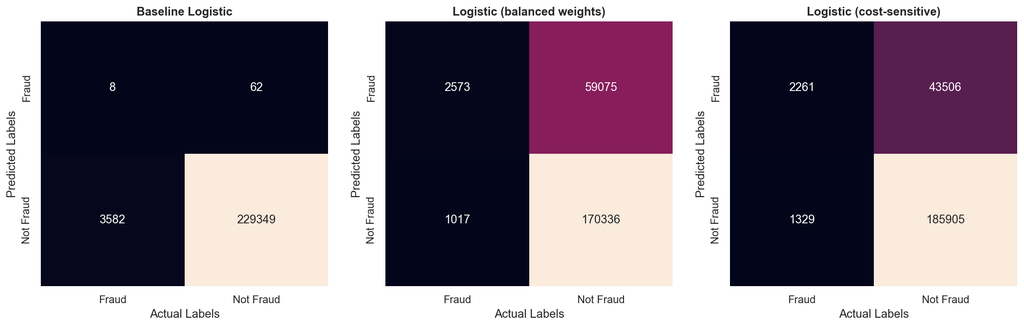

```python
# Confusion  Matrix

fig, ax = plt.subplots(1, 3, figsize=(18, 5))

cm1 = confusion_matrix(y_test, pred_lg1)
tn, fp, fn, tp = confusion_matrix(y_test, pred_lg1).ravel()
cm1 = [[tp,fp],[fn,tn]]

sns.heatmap(cm1, annot=True, fmt="d",cbar=False, ax = ax[0])
ax[0].set_title("Baseline Logistic", weight='bold')
ax[0].set_xlabel('Actual Labels')
ax[0].set_ylabel('Predicted Labels')
ax[0].yaxis.set_ticklabels(['Fraud', 'Not Fraud'])
ax[0].xaxis.set_ticklabels(['Fraud', 'Not Fraud'])

cm2 = confusion_matrix(y_test, pred_lg2)
tn, fp, fn, tp = confusion_matrix(y_test, pred_lg2).ravel()
cm2 = [[tp,fp],[fn,tn]]

sns.heatmap(cm2, annot=True, fmt="d",cbar=False, ax = ax[1])
ax[1].set_title("Logistic (balanced weights)", weight='bold')
ax[1].set_xlabel('Actual Labels')
ax[1].set_ylabel('Predicted Labels')
ax[1].yaxis.set_ticklabels(['Fraud', 'Not Fraud'])
ax[1].xaxis.set_ticklabels(['Fraud', 'Not Fraud'])

cm3 = confusion_matrix(y_test, pred_lg3)
tn, fp, fn, tp = confusion_matrix(y_test, pred_lg3).ravel()
cm3 = [[tp,fp],[fn,tn]]

sns.heatmap(cm3, annot=True, fmt="d",cbar=False, ax = ax[2])
ax[2].set_title("Logistic (cost-sensitive)", weight='bold')
ax[2].set_xlabel('Actual Labels')
ax[2].set_ylabel('Predicted Labels')
ax[2].yaxis.set_ticklabels(['Fraud', 'Not Fraud'])
ax[2].xaxis.set_ticklabels(['Fraud', 'Not Fraud'])

plt.show()
```

*Now the most important thing to notice here are the FN:*  
*- For baseline the FN is high but FP is pretty low*

*- For Logistic (balanced weights) the FN has dropped to about 1017 which is far better than baseline*

*- In cost sensitive training the FN increased but the FP dropped by a good amount, this is a typical showcasing of the trade-off between FP-FN*

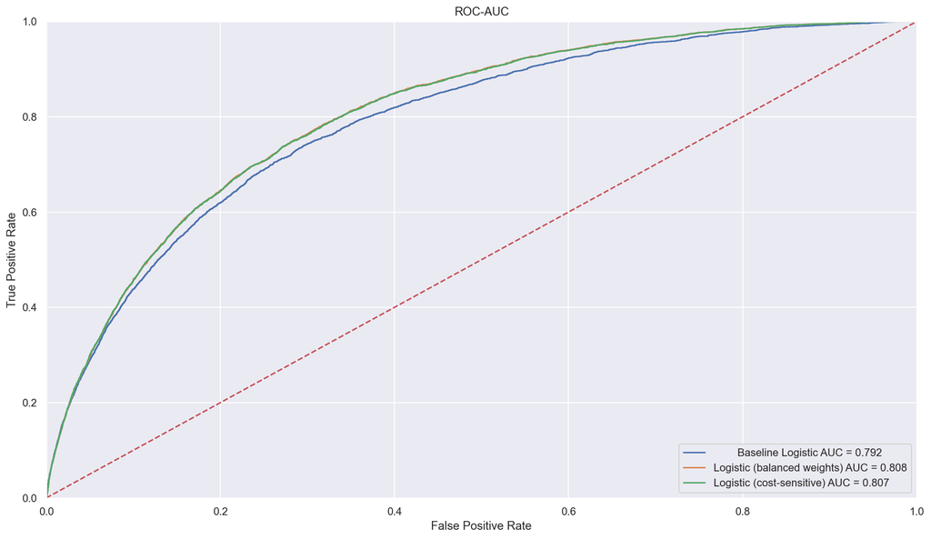

```python
# ROC-AUC curve
plot_roc(y_test, {"Baseline Logistic": pred_proba_lg1,
         "Logistic (balanced weights)": pred_proba_lg2, "Logistic (cost-sensitive)": pred_proba_lg3})
```

*The AUC of Logistic with balanced-weights is the best among the three though they all have almost simmilar AUC score*

### 2. Balanced Random Forest

**Balanced Random Forest**

BRF does sampling by iteratively drawing a bootstrap sample with equal proportions of data points from both the minority and the majority class.

```python
# StratifiedKfold cross validation (would take up coomputing power)
# model = BalancedRandomForestClassifier(class_weight='balanced')
# cv = RepeatedStratifiedKFold(n_splits=10, n_repeats=3, random_state=1)
# scores = cross_val_score(model, X_train_s, y_train, scoring='roc_auc', cv=cv, n_jobs=-1)
#print(f'The model ROC AUC mean is: {np.mean(scores):.3f}')

brf = BalancedRandomForestClassifier(
    n_estimators=150, class_weight='balanced', random_state=42)

brf.fit(X_train_s, y_train)
pred_brf = brf.predict(X_test_s)
pred_proba_brf = brf.predict_proba(X_test_s)[:, 1]
```

### 3. Easy Ensemble

The Easy Ensemble involves creating balanced samples of the training dataset by selecting all examples from the minority class and a subset from the majority class.Rather than using pruned decision trees, boosted decision trees are used on each subset, specifically the AdaBoost algorithm.

AdaBoost works by first fitting a decision tree on the dataset, then determining the errors made by the tree and weighing the examples in the dataset by those errors so that more attention is paid to the misclassified examples and less to the correctly classified examples.

```python
#base_estimator=AdaBoostClassifier()

eec = EasyEnsembleClassifier(
    n_estimators=150,n_jobs= -1, random_state=42)

eec.fit(X_train_s, y_train)
pred_eec = eec.predict(X_test_s)
pred_proba_eec = eec.predict_proba(X_test_s)[:, 1]
```

### 4. Weighted XGBoost

Two ways to handle imbalance here, these correspond to two different approaches to cost-sensitive learning.

- The sample_weight parameter allows you to specify a different weight for each training example.
- The scale_pos_weight parameter lets you provide a weight for an entire class of examples ("positive" class).

We can set the scale_pos_weight hyperparameter of the algorithm to indicate that our dataset has a certain ratio of positive and negative classes and XGBoost will take care of the rest.

scale_pos_weight is the ratio of number of negative class to the positive class. Best practices, if we want to train our XGBoost classifier on this dataset we would set the value of scale_pos_weight to be

[Counter({0: 535291, 1: 8376})] 535291/8376 = 63

```python
# StratifiedKfold cross validation (would take up coomputing power)
# model = XGBClassifier(class_weight='balanced')
# cv = RepeatedStratifiedKFold(n_splits=10, n_repeats=3, random_state=1)
# scores = cross_val_score(model, X_train_s, y_train, scoring='roc_auc', cv=cv, n_jobs=-1)
#print(f'The model ROC AUC mean is: {np.mean(scores):.3f}')

xgb = XGBClassifier(learning_rate=0.001, objective='binary:logistic',eval_metric="auc", n_estimators=100,
                    scale_pos_weight=63, random_state=42, n_jobs=-1, eta=0.15, gamma=2, max_depth=8)
xgb.fit(X_train_s, y_train)
pred_xgb = xgb.predict(X_test_s)
pred_proba_xgb = xgb.predict_proba(X_test_s)[:, 1]
```

**Classification Reports**

```python
# Classification Report
report_classification({"Balanced Random Forest": pred_brf,
                      "Easy Ensemble Classifier": pred_eec, "XGB classifier":pred_xgb})
```

```
Classification Report for Balanced Random Forest
              precision    recall  f1-score   support

           0       0.99      0.78      0.88    229411
           1       0.05      0.71      0.09      3590

    accuracy                           0.78    233001
   macro avg       0.52      0.75      0.48    233001
weighted avg       0.98      0.78      0.86    233001

--------------------------------------------------------------
Classification Report for Easy Ensemble Classifier
              precision    recall  f1-score   support

           0       0.99      0.74      0.85    229411
           1       0.04      0.73      0.08      3590

    accuracy                           0.74    233001
   macro avg       0.52      0.74      0.46    233001
weighted avg       0.98      0.74      0.84    233001

--------------------------------------------------------------
Classification Report for XGB classifier
              precision    recall  f1-score   support

           0       0.99      0.75      0.86    229411
           1       0.04      0.73      0.08      3590

    accuracy                           0.75    233001
   macro avg       0.52      0.74      0.47    233001
weighted avg       0.98      0.75      0.84    233001

--------------------------------------------------------------
```

*Balanced Random Forest, Easy ensemble & Weighted XGB have a pretty close results on minority. With BRF compromising a bit on recall. I would look at the confusion matrix to get more idea*

**ROC-AUC-PR Scores:**

- Balanced Random Forest
- Easy Ensemble
- Weighted XGBoost

```python
# auc & pr score
roc_auc_pr({"Balanced Random Forest": pred_proba_brf,
                      "Easy Ensemble Classifier": pred_proba_eec, "XGB classifier":pred_proba_xgb})
```

```
ROC-AUC score for Balanced Random Forest:
0.8275


PR-AUC score for Balanced Random Forest
0.0897
---------------------------
ROC-AUC score for Easy Ensemble Classifier:
0.8134


PR-AUC score for Easy Ensemble Classifier
0.0717
---------------------------
ROC-AUC score for XGB classifier:
0.8139


PR-AUC score for XGB classifier
0.1274
---------------------------
```

*The ROC-AUC score for Balanced Random forest is best among three. However the PR score for XBG is the best*

**Plot ROC-AUC Curves:**

- Baseline Logistic
- Logistic (balanced weights)
- Balanced Random Forest
- Easy Ensemble
- Weighted XGBoost

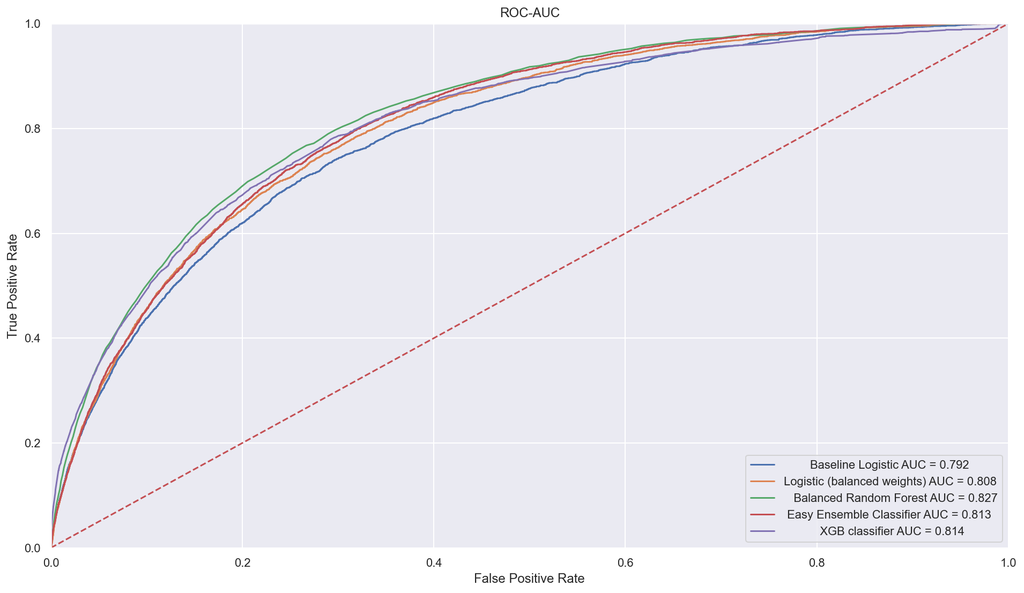

```python
plot_roc(y_test, {"Baseline Logistic": pred_proba_lg1, "Logistic (balanced weights)": pred_proba_lg2,
         "Balanced Random Forest": pred_proba_brf, "Easy Ensemble Classifier": pred_proba_eec, "XGB classifier": pred_proba_xgb})
```

**Plot ROC-PR Curves**

- Logistic (balanced weights)
- Balanced Random Forest
- Easy Ensemble
- Weighted XGBoost

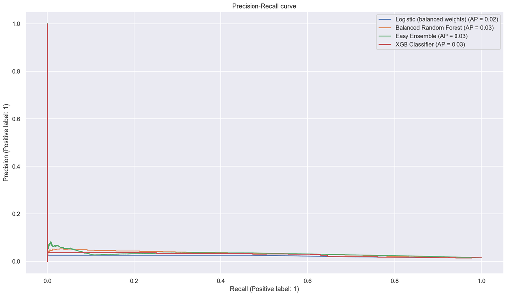

```python
plot_precision_recall_curve(lg2, X_test, y_test, ax = plt.gca(),name = "Logistic (balanced weights)")
plot_precision_recall_curve(brf, X_test, y_test, ax = plt.gca(),name = "Balanced Random Forest")
plot_precision_recall_curve(eec, X_test, y_test, ax = plt.gca(),name = "Easy Ensemble")
plot_precision_recall_curve(xgb, X_test, y_test, ax = plt.gca(),name = "XGB Classifier")
plt.legend(loc = 'upper right')
plt.title('Precision-Recall curve')
```

**Confusion Matrix**

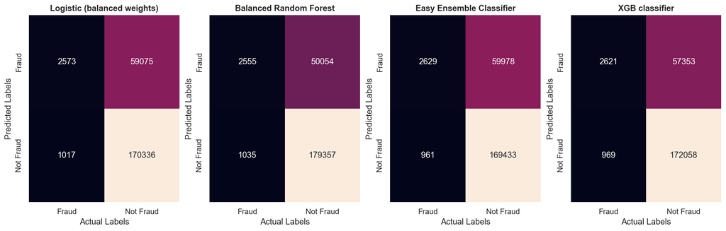

```python
# Confusion  Matrix

fig, ax = plt.subplots(1, 4, figsize=(18, 5))

cm1 = confusion_matrix(y_test, pred_lg2)
tn, fp, fn, tp = confusion_matrix(y_test,  pred_lg2).ravel()
cm1 = [[tp,fp],[fn,tn]]

sns.heatmap(cm1, annot=True, fmt="d",cbar=False, ax = ax[0])
ax[0].set_title("Logistic (balanced weights)", weight='bold')
ax[0].set_xlabel('Actual Labels')
ax[0].set_ylabel('Predicted Labels')
ax[0].yaxis.set_ticklabels(['Fraud', 'Not Fraud'])
ax[0].xaxis.set_ticklabels(['Fraud', 'Not Fraud'])

cm2 = confusion_matrix(y_test, pred_brf)
tn, fp, fn, tp = confusion_matrix(y_test, pred_brf).ravel()
cm2 = [[tp,fp],[fn,tn]]

sns.heatmap(cm2, annot=True, fmt="d",cbar=False, ax = ax[1])
ax[1].set_title("Balanced Random Forest", weight='bold')
ax[1].set_xlabel('Actual Labels')
ax[1].set_ylabel('Predicted Labels')
ax[1].yaxis.set_ticklabels(['Fraud', 'Not Fraud'])
ax[1].xaxis.set_ticklabels(['Fraud', 'Not Fraud'])

cm3 = confusion_matrix(y_test, pred_eec)
tn, fp, fn, tp = confusion_matrix(y_test, pred_eec).ravel()
cm3 = [[tp,fp],[fn,tn]]

sns.heatmap(cm3, annot=True, fmt="d",cbar=False, ax = ax[2])
ax[2].set_title("Easy Ensemble Classifier", weight='bold')
ax[2].set_xlabel('Actual Labels')
ax[2].set_ylabel('Predicted Labels')
ax[2].yaxis.set_ticklabels(['Fraud', 'Not Fraud'])
ax[2].xaxis.set_ticklabels(['Fraud', 'Not Fraud'])

cm4 = confusion_matrix(y_test, pred_xgb)
tn, fp, fn, tp = confusion_matrix(y_test, pred_xgb).ravel()
cm4 = [[tp,fp],[fn,tn]]

sns.heatmap(cm4, annot=True, fmt="d",cbar=False, ax = ax[3])
ax[3].set_title("XGB classifier", weight='bold')
ax[3].set_xlabel('Actual Labels')
ax[3].set_ylabel('Predicted Labels')
ax[3].yaxis.set_ticklabels(['Fraud', 'Not Fraud'])
ax[3].xaxis.set_ticklabels(['Fraud', 'Not Fraud'])

plt.show()
```

*Keeping the FN-FP in mind*

**Plot Feature Importance: Logistic**

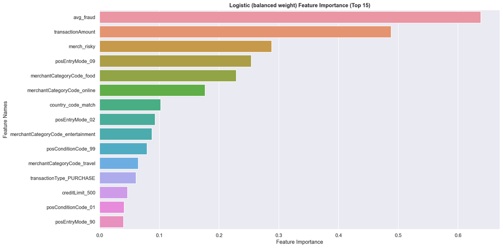

```python
plot_feature_importance(lg2.coef_[0],X_train.columns,'Logistic (balanced weight)')
```

**Plot Feature Importance: Balanced Random Forest**

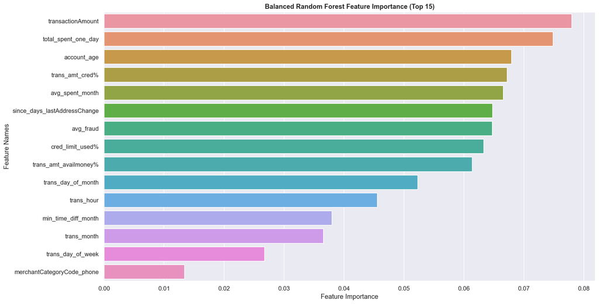

```python
plot_feature_importance(brf.feature_importances_,X_train.columns,'Balanced Random Forest')
```

**Plot Feature Importance: XGB Classifier**

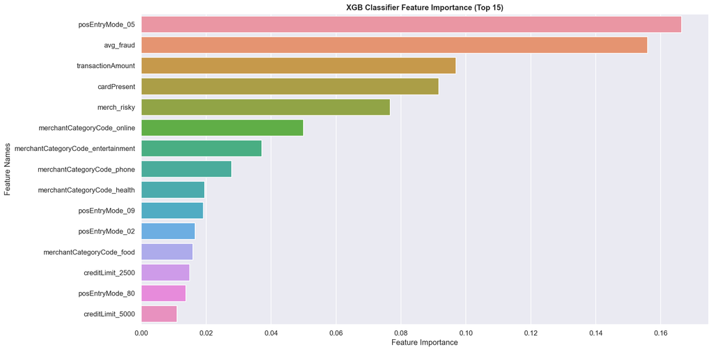

```python
plot_feature_importance(xgb.feature_importances_,X_train.columns,'XGB Classifier')
```

*Several of the new feature i made during the Feature engineering are being quite effective in modeling part as you can see from the Feature Importance plot, which is a good indication. I did follow a Backward Feature elimination step which i did not explicitly showcase here but i am mentioning it as a side note*

**Summary**

In the next approach I did oversampling and ran logistic, Random forest and XGB models which you can find in the Appendix section. I did not add those here since they provided high precision but low Recall in general, also they focus more on lowering the FP but the cases of FN went high.

## 6. Avoiding Data Leaks

Summary of steps/ approaches i kept in mind to avoid Data Leaks

- Standardizing

  *In the interest of preventing information about the distribution of the test set leaking into our model, i fitted the scaler on my training data only, then standardise both training and test sets with that scaler. By fitting the scaler on the full dataset prior to splitting, information about the test set is used to transform the training set, which in turn is passed downstream and introduces data leakage*
- Cross Validation

  *Splitting the data before apply Cross validation (startifiedkfold) will ensure there are no data leakage*
- oversampling

  *Split the date into test and train sets BEFORE trying sampling techniques and sampling must be only done on the training dataset*

## 7. Appendix

**List of models i tried but gave comparatively low performance**

- Random Forest with balanced class weight
- XGboost with computing class weights
- Imblearn: RandomOversampling with Logistic, Random Forest

```python
#################################     Random Forest with balanced class weight    ######################################

# from sklearn.ensemble import RandomForestClassifier
# rf1 = RandomForestClassifier(n_estimators=50, class_weight='balanced',
#                              random_state=42)
# rf1.fit(X_train,y_train)
# pred_rf1 = rf1.predict(X_test_s)
# pred_proba_rf1 = rf1.predict_proba(X_test_s)[:,1]

##########################      XGboost with computing class weights      ###############################################

# from sklearn.utils.class_weight import compute_sample_weight
# sample_weights = compute_sample_weight(
#     class_weight='balanced',
#     y=y_train #provide your own target name
# )

# xgb1 = XGBClassifier(learning_rate=0.001, objective='binary:logistic',eval_metric="auc", n_estimators=100,
#                     class_weight=sample_weights, random_state=42, n_jobs=-1, eta=0.15, gamma=2, max_depth=8)
# xgb1.fit(X_train_s, y_train)
# pred_xgb1 = xgb1.predict(X_test_s)
# pred_proba_xgb1 = xgb1.predict_proba(X_test_s)[:, 1]

# plot data points distribution
# for label, _ in counter.items():
#     row_ix = np.where(y == label)[0]
#     plt.scatter(X[row_ix, 0], X[row_ix, 1], label=str(label))
# plt.legend()
# plt.show()

#################################       RandomOverSampler           #####################################################

# from imblearn.over_sampling import RandomOverSampler
# print('Before Sampling: ')
# print(Counter(y_train))

# oversample = RandomOverSampler(sampling_strategy='minority')
# X_over, y_over = oversample.fit_resample(X_train, y_train)
# print('After Sampling: ')
# print(Counter(y_over))

# I tried using Randomoversampled data with logistic, Random forest and east ensemble. The precision was pretty high for them
# but the recall suffered a lot so I am mentioning this in the Appendix.
```

**Other Things I tried but restricted by computational power & time**

I strongly believe these methods- if incorporated will improve the performance by a good margin. I did ran these but my laptop crashed several times, the voting classifier & Smotetomek code ran for couple of hours before crashing.

- Stacking: VotingClassifier
- XGB: Hyperparameter Tuning with Stratified Kfold and GridsearchCV
- Hybrid Sampling: SMOTETomek

```python
###############################    1. VotingClassifier    #######################################################

# estimator = []
# estimator.append(('BRF',BalancedRandomForestClassifier(n_estimators=150, class_weight='balanced', random_state=42)))
# estimator.append(('SVC', SVC(gamma ='auto', class_weight='balanced',probability = True, random_state=42)))
# estimator.append(('DTC', DecisionTreeClassifier(class_weight='balanced', random_state=42)))
# # Voting Classifier with hard voting
# vot_hard = VotingClassifier(estimators = estimator, voting ='hard')
# vot_hard.fit(X_train_s, y_train)
# pred_vh = vot_hard.predict(X_test_s)
# pred_proba_vh = vot_hard.predict(X_test_s)[:, 1]

# # using accuracy_score metric to predict accuracy
# #score = accuracy_score(y_test, y_pred)
# #print("Hard Voting Score % d" % score)

# # Voting Classifier with soft voting
# vot_soft = VotingClassifier(estimators = estimator, voting ='soft')
# pred_vs = vot_soft.predict(X_test_s)
# pred_proba_vs = vot_soft.predict(X_test_s)[:, 1]

# #using accuracy_score
# #score = accuracy_score(y_test, y_pred)
# #print("Soft Voting Score % d" % score


#################################    2. XGBoost Hyperparameter Training   ######################################

# def xgboost_search(X, y, search_verbose=1):
#     params = {
#         "gamma":[0.5, 1, 1.5, 2, 5],
#         "max_depth":[3,4,5,6],
#         "min_child_weight": [100],
#         "subsample": [0.6, 0.8, 1.0],
#         "colsample_bytree": [0.6, 0.8, 1.0],
#         "learning_rate": [0.1, 0.01, 0.001]
#     }
#     xgb = XGBClassifier(objective="binary:logistic", eval_metric="auc", use_label_encoder=False)
#     skf = StratifiedKFold(n_splits=3, shuffle=True, random_state=42)
#     randomized_search = RandomizedSearchCVestimator=xgb, param_grid=params, scoring="roc_auc", n_jobs=1, cv=skf.split(X,y), verbose=search_verbose)
#     --grid_search = GridSearchCV(estimator=xgb, param_grid=params, scoring="roc_auc", n_jobs=1, cv=skf.split(X,y), verbose=search_verbose)
#     --grid_search.fit(X, y)
#     print("Best estimator: ")
#     print(grid_search.best_estimator_)
#     print("Parameters: ", grid_search.best_params_)
#     print("Highest AUC: %.2f" % grid_search.best_score_)
#     return grid_search.best_params_


########################################   3. SMOTETomek    #####################################################################


# from imblearn.combine import SMOTETomek
# print('Before Hybrid Sampling: ')
# print(Counter(y_train))
# smtom = SMOTETomek(random_state=42)

# X_train_smtom, y_train_smtom =  smtom.fit_resample(X_train, y_train)
# print('After Hybrid Sampling: ')
# print(Counter(y_train))
```

## 8. Future work

Since i had quite limited time and computaional power at my disposal I tried what i could with that limitation however there are several ideas/approaches i would have pursued given more time and computational power. Some of them you already saw above in the Appendix section.

**More Feature engineering**

*Generate more merchant related aggregate features, time related more granular features*

**Sampling techniques**

*Combo of various upsampling & undersampling techniques with applying the models of these subsets to see what gives just the best trade-off - Smote+ENN, pipeline of Under & oversampling*

**Hyperparameter tuning: GridsearchCV**

*I tried randomized grid search with only few variables as I was quite restricted by the computaional power i had but ideally i would want to experiment with much larger set of parameters on gridsearchCV (it's claculated all combinations unlike RandomizedCV) as I think it will enchance our performance*

**Ensemble & boosting**

*Trying various combinations of Stacking/ ensemble models and trying out other boosting models CAT/Lgbm*

**Learn about Autoencoders**

*I have not worked with autoencoders and i don't have much idea about the topic but this would be a good oppurtunity to learn about it as it helps in detecting anomalies/fraudulent patterns*

**Tweaking Threshold**

*In AUC-ROC the default threshold is 0.5 but i can experiment and tweak to see the ideal tradeoff by setting different thresholds (that would require internal business insights to capital one)*

**Multiple Recursive Feature Selection**

*Though i did use this approach here but with more time i would do a lot more iterations & choose the most important features and retrain the model using the handful selected features*

**Access to cloud/clusters**

*With access to higher computational power,I am confident that i can increase the performance by a good margin.*

## 9. References

https://scikit-learn.org/stable/

https://sebastianraschka.com/

https://www.analyticsvidhya.com

https://stackoverflow.com/

https://www.google.com/